# Exploratory Data Analysis on the Washigton crime report

Vishal Fulsundar, Suraj kapare, Halima Al Balushi, Naiska Buyandalai

2024-12-13

```r
# some of common options (and the defaults) are:
# include=T, eval=T, echo=T, results='hide'/'asis'/'markup',..., collapse=F, warning=T, message=T, error=T, cache=T, fig.width=6, fig.height=4, fig.dim=c(6,4) #inches, fig.align='left'/'center','right',
knitr::opts_chunk$set(warning = F, results = "markup", message = F)
# knitr::opts_chunk$set(warning = F, results = "hide", message = F)
options(scientific=T, digits = 3)
```

# **Introduction** —-

Introduction: In our project, we aim to investigate crime patterns in Washington, DC, utilizing data from the Open Data DC portal. The dataset, “Crime Incidents in 2023,” comprises 34,215 observations detailing reported crimes, including information on the type of offense, time of occurrence, geographic location, and methods involved. As individuals, especially students, consider buying a house, renting an apartment, relocating, or traveling, one of the first questions that arises is, “Is it safe?” This concern for safety drives many to seek out neighborhoods with low crime rates before evaluating other factors such as price, amenities, and accessibility. Therefore, understanding crime dynamics is crucial not only for law enforcement but also for residents and potential newcomers to the area. The primary focus of our analysis is to explore crime density across different areas of Washington, DC, identifying neighborhoods that experience the highest levels of criminal activity. This exploration aims to uncover patterns that can inform law enforcement resource allocation and guide community safety initiatives aimed at crime prevention. By providing insights into crime trends, we hope to empower individuals and families to make informed decisions regarding their living environments.

# **Data Sources**:

Crime Incidents in Washington, DC (2023): Link: Crime Incidents in 2023 Description: This dataset serves as the primary source for our analysis, encompassing 34,215 reported crime incidents in Washington, DC. It includes critical information such as the type of offense, time of occurrence, geographic location, and methods involved. This comprehensive dataset is essential for examining crime patterns and densities across different neighborhoods

Our Main data frame named- Crime_data have records around 34215observation including the 25 variables. The data set(crime_data) give overiew of the potensial varibles in the dataset.These varible give /provide the details view of the each incident,enabling us to analyze across dimensions like geographical location, type of offense, time of occurrence, and associated methods as well as timing of the occurence betwnn the shift(day,evening,midnight). ex 1) Type of offence- nature of the crime, such as theft, assault, or vandalism, allowing us to categorize and compare crime types 2) Shift of occurence- shift the crime happened, which can reveal temporal patterns or peak crime times. 3)Method Involved: Provides information on any specific method or weapon(knief,gun,other) used in the offense 4)District or Area: The specific district or police jurisdiction involved,

```r
crime_data <- read.csv("C:/Users/DELL/Documents/GitHub/crime-analysis-washington-dc-2023/Crime_Incidents_in_2023.csv")
```

Neighborhood Clusters: Link: Neighborhood Clusters Description: This dataset provides a mapping of numerical identifiers for neighborhoods to more recognizable names, such as Columbia Heights, Georgetown, and Dupont Circle. By integrating this data, we enhance the interpretability of our analysis, making it easier for stakeholders to understand the geographic context of crime data.

Cluster has 46 observations and 2 variables and data frame represent neighborhood clusters in Washington, DC. NBH_NAMES: This column contains the full names of the neighborhoods within each cluster. NAME: This column contains the cluster identifier (e.g., “Cluster 16”, “Cluster 41”), which is a unique numerical label for each neighborhood cluster.

```r
library(dplyr)
cluster <- read.csv("C:/Users/DELL/Documents/GitHub/crime-analysis-washington-dc-2023/Neighborhood_Clusters.csv")

cluster <- cluster %>%  select(NAME,NBH_NAMES)
```

DC Police Stations: Link: DC Police Stations Description: This dataset contains the locations of police stations across Washington, DC. Incorporating this information allows us to analyze the proximity of law enforcement resources to neighborhoods with varying crime rates, offering insights into potential coverage gaps.

Dc police station data frame have dataframe has 15 observations and 23 variables, some variables for examples are Zip code , address, lattitude, longitude ,Type, name.

```r
# Reading Police Stations data
police_stations <- read.csv("C:/Users/DELL/Documents/GitHub/crime-analysis-washington-dc-2023/Police_Stations.csv")
```

# ** Library** —-

WE have loaded the required library here ggplot2: Used for creating static visualizations, such as line graphs, bar charts, and scatter plots.

dplyr: A data manipulation package that provides functions to filter, arrange, and summarize data.

lubridate: Simplifies date and time manipulation, making it easier to work with date formats, extract time components, and perform calculations.

sf: Provides support for handling spatial data, allowing you to analyze and visualize geographic data.

leaflet: Used for creating interactive maps, often integrating spatial data from the sf package.

```r
# 2) load the require library

library(ggplot2)
library(dplyr)
# ggplot library for graphs
library(lubridate) # fro thr data manupulation
library(sf)
library(leaflet)
```

# **data collection**

from the is.null operator , we got that there is no record in the OCTO_RECORD_ID column. total 34215 records are missing from the records.

DISTRICT: 285 records are missing district details. PSA (Police Service Area): 298 records lack PSA information, which might impact analyses that involve crime distribution across service areas. CENSUS_TRACT: 16 records are missing census tract data, which could slightly affect demographic or geographic analyses at the census level. OCTO_RECORD_ID: All 34,215 records are missing from the recoreds . so, we have to remove all these recoreds for the eda. From the column named OCTO_RECORD_ID al 34,215 recoreds are missing, so we have to remove this column. We do not require that column. del.

```r
colnames(crime_data)
```

```
##  [1] "X"                    "Y"                    "CCN"
##  [4] "REPORT_DAT"           "SHIFT"                "METHOD"
##  [7] "OFFENSE"              "BLOCK"                "XBLOCK"
## [10] "YBLOCK"               "WARD"                 "ANC"
## [13] "DISTRICT"             "PSA"                  "NEIGHBORHOOD_CLUSTER"
## [16] "BLOCK_GROUP"          "CENSUS_TRACT"         "VOTING_PRECINCT"
## [19] "LATITUDE"             "LONGITUDE"            "BID"
## [22] "START_DATE"           "END_DATE"             "OBJECTID"
## [25] "OCTO_RECORD_ID"
```

```r
colSums(is.na(crime_data))
```

```
##                    X                    Y                  CCN
##                    0                    0                    0
##           REPORT_DAT                SHIFT               METHOD
##                    0                    0                    0
##              OFFENSE                BLOCK               XBLOCK
##                    0                    0                    0
##               YBLOCK                 WARD                  ANC
##                    0                    5                    0
##             DISTRICT                  PSA NEIGHBORHOOD_CLUSTER
##                  285                  298                    0
##          BLOCK_GROUP         CENSUS_TRACT      VOTING_PRECINCT
##                    0                   16                    0
##             LATITUDE            LONGITUDE                  BID
##                    0                    0                    0
##           START_DATE             END_DATE             OBJECTID
##                    0                    0                    0
##       OCTO_RECORD_ID
##                34215
```

```r
# Check for duplicate rows from the data set
duplicates <- crime_data[duplicated(crime_data), ]
nrow(duplicates)
```

```
## [1] 0
```

Now, we going to check the indual column null values, PSA (Police Service Area): A total of 33,917 records have non-missing values, indicating that a significant number of incidents have an associated PSA. CENSUS_TRACT: 34,199 records are populated, suggesting that the majority of entries include census tract information. DISTRICT: 33,930 records are complete, showing that most incidents are assigned to a specific district. WARD: There are 5 missing records in this column, which means that only a small fraction of incidents lack associated ward information. Overall, the dataset is mostly complete for key geographic identifiers, with the exception of the WARD column, which has a minimal number of missing values. This completeness enhances the reliability of our analysis related to crime patterns in Washington, DC.

```r
sum(!is.na(crime_data$PSA))          # Check rows with PSA not missing
```

```
## [1] 33917
```

```r
sum(!is.na(crime_data$CENSUS_TRACT)) # Check rows with CENSUS_TRACT not missing
```

```
## [1] 34199
```

```r
sum(!is.na(crime_data$DISTRICT))     # Check rows with DISTRICT not missing
```

```
## [1] 33930
```

```r
sum(is.na(crime_data$WARD))          # Check rows with WARD missing
```

```
## [1] 5
```

# **Data Preprocessing** —

To prepare the data, we performed a series of preprocessing steps including cleaning, handling missing values, and transforming data types

we have to delete these null values , we had founded null from values ward , (census_tract) (geographical region ) , district, psa (public safty areas ) To ensure the quality of our dataset, we need to remove the records with null values in the WARD, CENSUS_TRACT, DISTRICT, and PSA.

```r
crime_data1 <- crime_data[
    !is.na(crime_data$PSA) &
    !is.na(crime_data$CENSUS_TRACT) &
    !is.na(crime_data$DISTRICT)
    ,
]
nrow(crime_data1)
```

```
## [1] 33899
```

check Null Values-

cheking the duplicate values in the dataset.

```r
# check duplicate values
# Ensure crime_data1 is a data frame
crime_data1 <- as.data.frame(crime_data1)

duplicate_crime_data <- crime_data1[duplicated(crime_data1), ]
```

Duplicate— so we don’t have duplicate vlaues in the data set also .

now our data set is net and clean . we are ready for the data transformation . now we have to convert some rows of data in to some other formate beacuse of our need . we some time trand=sform the solumns as according to our use of that data . for more readiblity of the data set , means we have the data formate YY/mm/DD HH/MM/SS, as we want to annalyis the data as month as well as day wise , we have to extract the months and days from this formate. create the new columns Year and month from the column Report_dat. as you can see the 2 columns are newly added at the ends of the data-frame.

```r
head(crime_data1)
```

```
##        X      Y      CCN             REPORT_DAT    SHIFT METHOD
## 1 396736 140470 23120415 2023/07/25 05:09:14+00 MIDNIGHT OTHERS
## 2 397177 146810 23047033 2023/03/27 06:12:11+00 MIDNIGHT    GUN
## 3 398478 137857 23187303 2023/11/15 19:31:25+00      DAY OTHERS
## 4 396659 137377 23055316 2023/04/10 06:13:40+00 MIDNIGHT OTHERS
## 5 397874 139955 23056311 2023/04/11 23:18:47+00  EVENING OTHERS
## 6 400976 133256 23156424 2023/09/22 13:39:32+00      DAY OTHERS
##               OFFENSE                                                BLOCK
## 1             ROBBERY                    1600 - 1699 BLOCK OF PARK ROAD NW
## 2             ROBBERY              8129  - 8148 BLOCK OF EASTERN AVENUE NW
## 3         THEFT/OTHER                       400 - 499 BLOCK OF O STREET NW
## 4        THEFT F/AUTO                  1100 - 1129 BLOCK OF 17TH STREET NW
## 5 MOTOR VEHICLE THEFT                   700 - 999 BLOCK OF HOBART PLACE NW
## 6             ROBBERY 1900 - 1999 BLOCK OF MARTIN LUTHER KING JR AVENUE SE
##   XBLOCK YBLOCK WARD ANC DISTRICT PSA NEIGHBORHOOD_CLUSTER BLOCK_GROUP
```

[output cut: 20 more lines]

```r
crime_data1$REPORT_DAT <- as.Date(crime_data1$REPORT_DAT, formate="%m/%d/%Y")

# extract the year and month also for future plots

crime_data1$Year <- format(crime_data1$REPORT_DAT,"%Y")
crime_data1$Month <- format(crime_data1$REPORT_DAT,"%m")

head(crime_data1)
```

```
##        X      Y      CCN REPORT_DAT    SHIFT METHOD             OFFENSE
## 1 396736 140470 23120415 2023-07-25 MIDNIGHT OTHERS             ROBBERY
## 2 397177 146810 23047033 2023-03-27 MIDNIGHT    GUN             ROBBERY
## 3 398478 137857 23187303 2023-11-15      DAY OTHERS         THEFT/OTHER
## 4 396659 137377 23055316 2023-04-10 MIDNIGHT OTHERS        THEFT F/AUTO
## 5 397874 139955 23056311 2023-04-11  EVENING OTHERS MOTOR VEHICLE THEFT
## 6 400976 133256 23156424 2023-09-22      DAY OTHERS             ROBBERY
##                                                  BLOCK XBLOCK YBLOCK WARD ANC
## 1                    1600 - 1699 BLOCK OF PARK ROAD NW 396736 140470    1  1D
## 2              8129  - 8148 BLOCK OF EASTERN AVENUE NW 397177 146810    4  4A
## 3                       400 - 499 BLOCK OF O STREET NW 398478 137857    2  2G
## 4                  1100 - 1129 BLOCK OF 17TH STREET NW 396659 137377    2  2C
## 5                   700 - 999 BLOCK OF HOBART PLACE NW 397874 139955    1  1E
## 6 1900 - 1999 BLOCK OF MARTIN LUTHER KING JR AVENUE SE 400976 133256    8  8A
##   DISTRICT PSA NEIGHBORHOOD_CLUSTER BLOCK_GROUP CENSUS_TRACT VOTING_PRECINCT
```

[output cut: 20 more lines]

# **Reframe Data frame**

we can see that , 2 new columns are added at the end of the all columns. now readjust columns, add these columns in the data frame after the REPOST_DAT.

rearrange the columns and move the columns YEAR and Month after the report year .

```r
crime_data1 <- crime_data1 %>%
    select(1:which(colnames(crime_data1) == "REPORT_DAT"), Year, Month, everything())
```

# **Normalization(Optional)**:

first thing, for the eda part stastical test, we don;t require normalization prcosess. If we want to make a model on the dataset then pnly we have to do normalzition.

now we have to normalize the data set Beacuse ———- 1) uniformality across the featurre- in the data set we have geo location data , date time data ,character data (shift ), numerical data(disctrict ) some pincode , so our data have SACLE are drastically different , if we don;t normalize , some time anlalysis will affect

2. it will help in the improving the speed in analysis
3. avoid the feature domination effect some feature are x, y co ordinate values are greater than the ward number , so to avioid these domination we have to noramzalise the data set .

```r
# select the columns , on whcih we have to process the normalize the data.
# libriry "dplyr" require for the normalize the data .
# Select numerical columns that need to be normalized
# Exclude categorical columns like OFFENSE, SHIFT, METHOD, etc.
# Select only numeric columns that should be normalized
numeric_columns <- crime_data1 %>%
  select(X, Y, XBLOCK, YBLOCK, LATITUDE, LONGITUDE)
# Apply Min-Max normalization for each numeric column
normalize <- function(x) {
  return((x - min(x)) / (max(x) - min(x)))
}

# Apply normalization to the numeric columns
normalized_numeric_columns <- as.data.frame(lapply(numeric_columns, normalize))

# Add back the non-numeric columns to the normalized dataset
crime_data2 <- bind_cols(crime_data1 %>% select(-X, -Y, -XBLOCK, -YBLOCK, -LATITUDE, -LONGITUDE),
                          normalized_numeric_columns)
```

# **Summary Stastics**–

Now start the EDA- Exploratory Data Analysis

summary stastics—– In this section, we present the summary statistics of the dataset, which provide an overview of the key characteristics of the data.

```r
crime_data2 <- crime_data2 %>%
  left_join(cluster, by = c("NEIGHBORHOOD_CLUSTER" = "NAME"))
```

1. report date- show the range of the date, when 1st offence dtae started to the last date of the offence date. even report date information is avaible in the quater wise.
2. most of the varibles are catogica like ward, shift, block, methods. in the next, part we will convert some of the variable into int value.

now we will check with the count(summanry) wise variable.

```r
# Summarize total offenses by ward
offense_total_by_ward <- crime_data2 %>%
  group_by(WARD) %>%
  summarise(Total_Offenses = n())
```

Ward wise total offence first we have to know , what type of theft it is normally happening in DC. for reference 1) Theft F/Auto (Theft from Auto)— #This type of theft refers to property stolen from a vehicle. It typically includes items such as: Personal belongings (e.g., bags, electronics, and clothing) 2) Motor vehicle theft refers to the unlawful taking or stealing of a vehicle itself. This includes:Cars, trucks, motorcycles, and other motor vehicles

3. Theft/Other–This category encompasses various types of thefts that do not fit into the more specific categories. It may include:– item lifting from retail stores, Theft of items from homes
4. Arson—- is the criminal act of deliberately setting fire to property. It can involve burning buildings, vehicles, or other structures

```r
offence_count <- crime_data2 %>%
  group_by(OFFENSE)%>%
  summarise(count=n())
```

Offence_type Vs count– The numbers indicate that Theft from Auto and Motor Vehicle Theft are significant issues, highlighting the importance of vehicle security. and least with the Arson type of the offence.

now we are looking the offence by the shift wise with the count wise. mean we will know in which shift most of the offence happen, by which method as well as , which type of the offence. so that we can micro - analyze these things.

EVENING (13148)— count here is the highest among the three shifts, indicating that more offenses happen during this time. Understanding the distribution of crimes by shift can help in analyzing crime trends and identifying times when specific types of crimes are more prevalent, allowing for targeted interventions

```r
# Group by SHIFT and summarize the count of offenses
offence_by_shift <- crime_data2 %>%
  group_by(SHIFT) %>%
  summarise(Count = n(), .groups = 'drop')
```

crime count by shift

count by method – Least Common Offenses— The offenses with the lowest counts include various types of arson and sex abuse, predominantly occurring during the midnight and day shifts. Notably, arson incidents are quite rare, especially during evening and midnight hours. Highest Common Offenses: Conversely, theft-related offenses dominate the statistics, particularly the “THEFT/OTHER” category, with significant occurrences in both the evening and daytime shifts. This indicates that theft crimes are more prevalent, especially during peak hours when more people are likely to be out.

```r
# Check if SHIFT is a factor or convert it to one if needed
crime_data2$SHIFT <- as.factor(crime_data2$SHIFT)

library(dplyr)

# Ensure SHIFT is a factor
crime_data2$SHIFT <- as.factor(crime_data2$SHIFT)

offence_by_shift <- crime_data2 %>%
  group_by(SHIFT, OFFENSE) %>%
  summarise(Count = n(), .groups = 'drop') %>%
  arrange(desc(Count))

# Check the structure of the resulting data frame
#str(offence_by_shift)
#head(offence_by_shift)
# Print the summary table
print(offence_by_shift)
```

```
## # A tibble: 25 × 3
##    SHIFT    OFFENSE             Count
##    <fct>    <chr>               <int>
##  1 EVENING  THEFT/OTHER          5616
##  2 DAY      THEFT/OTHER          5433
##  3 DAY      THEFT F/AUTO         3352
##  4 EVENING  THEFT F/AUTO         2926
##  5 DAY      MOTOR VEHICLE THEFT  2752
##  6 EVENING  MOTOR VEHICLE THEFT  2529
##  7 MIDNIGHT THEFT/OTHER          2029
##  8 MIDNIGHT ROBBERY              1619
##  9 MIDNIGHT MOTOR VEHICLE THEFT  1455
## 10 MIDNIGHT THEFT F/AUTO         1412
## # ℹ 15 more rows
```

District Vs Count—- District 3 has the highest total count of offenses with 6612 incidents, indicating it may have higher crime activity or reporting in comparison to others. District 7 shows the lowest total count at 2883

```r
# Summarize the count of offenses by district
OFFENCE_BY_DISTRICT <- crime_data2 %>%
  group_by(DISTRICT) %>%
  summarise(count = n(), .groups = 'drop')  # 'drop' will ungroup after summarizing
# Print the summarized table
print(OFFENCE_BY_DISTRICT)
```

```
## # A tibble: 7 × 2
##   DISTRICT count
##      <int> <int>
## 1        1  4533
## 2        2  5596
## 3        3  6612
## 4        4  4341
## 5        5  5605
## 6        6  4329
## 7        7  2883
```

As we know most of the varibles are catagorical - analyze the correlation between categorical columns in dataset, we can use various methods since correlation typically applies to numerical data. But the numerical data we have like longitude and lattitude , as well as CNN, Report date , but we don;t require numerical data coraltion of this varible.

# **EDA**

4.1)crime count by shift…. exploratory data analysis.

```r
# Crime count based on Shift
library(ggplot2)

offense_by_shift_funnel <- crime_data2 %>%
  group_by(SHIFT) %>%
  summarise(Total_Offenses = n(), .groups = 'drop') %>%
  arrange(desc(Total_Offenses))  # Arrange shifts by number of offenses
```

4.2) Distrubution of crime offense

distrubution of the crime offence by type of the offence

so the most common offence is Theft/other , followed by theft/auto —

4.3) Distribution of different offenses by shift—-

4.4)METHOD OF OFFENCE VS OFFENCE——-

Robbery Offenses: We see a noticeable spike in robbery incidents during midnight, which is pretty significant. In fact, robbery offenses outnumber motor vehicle thefts during this time!

Dangerous Weapons: There’s also a rise in the use of dangerous weapons, particularly in the evening and midnight hours.

4.5)Distribution of offenses method by shift— Dangerous Weapons– Gun and knif : There’s also a rise in the use of dangerous weapons, particularly in the evening and midnight hours

4.7) Seasonal Crime pattern

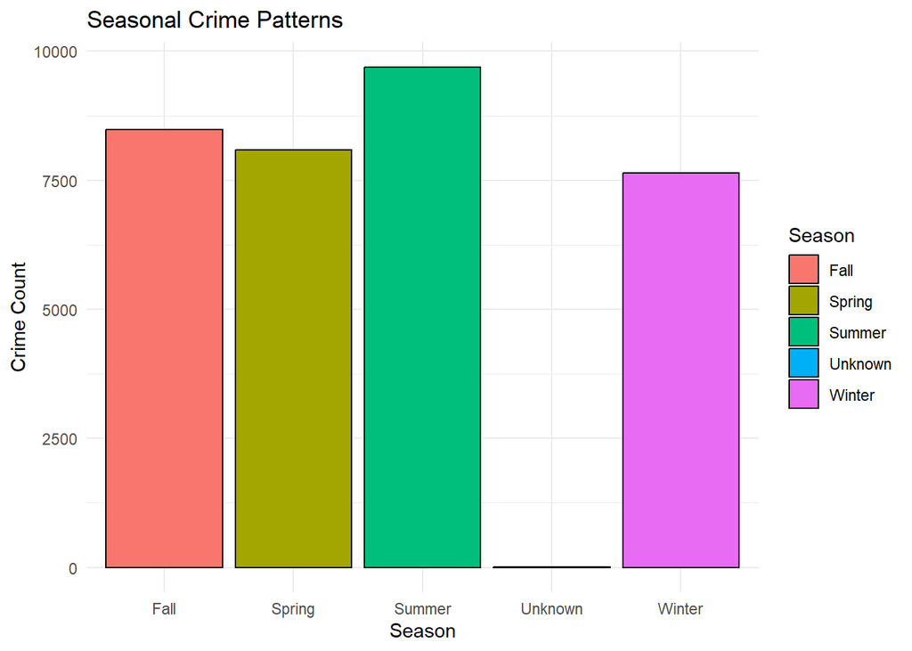

```r
# Ensure START_DATE is in Date format
crime_data2$START_DATE <- as.Date(crime_data2$START_DATE)

# Extract year and month
crime_data2$Year <- format(crime_data2$START_DATE, "%Y")  # Extracting the year as a string
crime_data2$Month <- format(crime_data2$START_DATE, "%b")  # Extracting abbreviated month names

# Define seasons based on months (northern hemisphere)
crime_data2$Season <- case_when(
  crime_data2$Month %in% c("Dec", "Jan", "Feb") ~ "Winter",
  crime_data2$Month %in% c("Mar", "Apr", "May") ~ "Spring",
  crime_data2$Month %in% c("Jun", "Jul", "Aug") ~ "Summer",
  crime_data2$Month %in% c("Sep", "Oct", "Nov") ~ "Fall",
  TRUE ~ "Unknown"  # Catch-all for any unexpected month values
)

# Group by season and summarize total crime count per season
crime_by_season <- crime_data2 %>%
  group_by(Season) %>%
  summarise(Count = n(), .groups = 'drop')

# Group by month and summarize total crime count per month
crime_by_month <- crime_data2 %>%
  group_by(Month) %>%
  summarise(Count = n(), .groups = 'drop')

# Plot crime counts by season to identify seasonal patterns
ggplot(crime_by_season, aes(x = Season, y = Count, fill = Season)) +
  geom_bar(stat = "identity", color = "black") +
  labs(title = "Seasonal Crime Patterns", x = "Season", y = "Crime Count") +
  theme_minimal()
```

```r
# Ensure date columns are in proper date format
crime_data2$START_DATE <- as.Date(crime_data2$START_DATE)

# Extract the year and month from the START_DATE column
crime_data2$YearMonth <- format(crime_data2$START_DATE, "%Y-%m")

# Filter the data to include only from January 2023
crime_data_filtered <- crime_data2 %>%
  filter(YearMonth >= "2022-12")

# Group by YearMonth and count the number of offenses
offense_by_month <- crime_data_filtered %>%
  group_by(YearMonth) %>%
  summarise(Count = n(), .groups = 'drop')
```

4.8) shift vs offence

```r
# Summarize the count of offenses by SHIFT and OFFENSE
offense_by_shift_summary <- crime_data2 %>%
  group_by(SHIFT, OFFENSE) %>%
  summarise(Total_Offenses = n(), .groups = 'drop')
# here we replace the barplot with pie chart
```

```r
library(dplyr)
library(ggplot2)

offense_summary <- crime_data2 %>%
  group_by(OFFENSE) %>%
  summarise(Count = n(), .groups = 'drop') %>%
  arrange(desc(Count))
```

```r
# Summarize total offenses by ward
offense_total_by_ward <- crime_data2 %>%
  group_by(WARD) %>%
  summarise(Total_Offenses = n())
```

```r
# Summarize offense counts by Shift
offense_by_shift <- crime_data2 %>%
  group_by(SHIFT, OFFENSE) %>%
  summarise(Count = n(), .groups = 'drop')
```

4.8) coorrelation– between numerical variables x,y ,ward, latitude , longitude

```r
# Select numeric columns for correlation analysis
numeric_columns <- crime_data2 %>%
  select(X, Y, LATITUDE, LONGITUDE, PSA, WARD, DISTRICT)

# Check the structure of numeric columns
```

```r
# Convert non-numeric columns to numeric (if necessary)
numeric_columns <- crime_data2 %>%
  select(X, Y, LATITUDE, LONGITUDE, PSA, WARD, DISTRICT) %>%
  mutate(across(everything(), ~ as.numeric(.)))

# Check structure to confirm all columns are now numeric
```

# **correlation_matrix** -

```r
# Calculate the correlation matrix
correlation_matrix <- cor(numeric_columns, use = "complete.obs")

# Print the correlation matrix
print(correlation_matrix)
```

```
##                X      Y LATITUDE LONGITUDE    PSA   WARD DISTRICT
## X          1.000 -0.453   -0.453     1.000  0.624  0.723    0.623
## Y         -0.453  1.000    1.000    -0.453 -0.343 -0.611   -0.339
## LATITUDE  -0.453  1.000    1.000    -0.453 -0.343 -0.611   -0.339
## LONGITUDE  1.000 -0.453   -0.453     1.000  0.624  0.723    0.623
## PSA        0.624 -0.343   -0.343     0.624  1.000  0.540    1.000
## WARD       0.723 -0.611   -0.611     0.723  0.540  1.000    0.540
## DISTRICT   0.623 -0.339   -0.339     0.623  1.000  0.540    1.000
```

```r
# Set a CRAN mirror
options(repos = c(CRAN = "https://cloud.r-project.org/"))

# Load necessary libraries or install if not available
if (!requireNamespace("corrplot", quietly = TRUE)) {
  install.packages("corrplot")
}
```

Correlation plot.

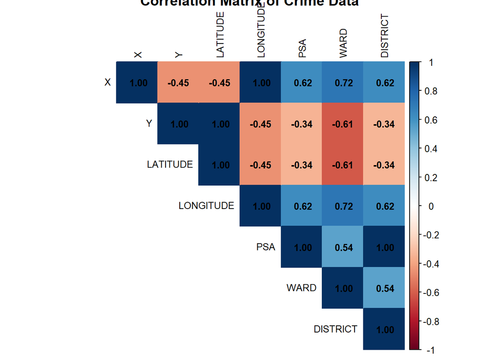

```r
library(corrplot)


# Calculate the correlation matrix
correlation_matrix <- cor(numeric_columns, use = "complete.obs")

# Plot the correlation matrix using corrplot
corrplot(correlation_matrix, method = "color", type = "upper",
         tl.col = "black", tl.cex = 0.8, number.cex = 0.8,
         addCoef.col = "black", title = "Correlation Matrix of Crime Data")
```

```r
library(ggplot2)
library(sf)
library(dplyr)
library(tidycensus)
```

```r
library(devtools)

#devtools::install_github("BingoLaHaye/DCmapR")
```

```r
library(DCmapR)
#devtools::install_github("BingoLaHaye/DCmapR")
```

Stastical Test–

Lets start with the Stastical test now

Chi-Square Test Results - (shift and offence type) chi-square test fir shift and offence type. Null Hypothesis (H0): There is no association between Shift and Offense type.

Alternative Hypothesis (H1): There is an association between Shift and Offense type. This indicates that the distribution of offense types is dependent on the time of day (Shift).

```r
# Load necessary library
library(dplyr)

# Create a contingency table for Shift and Offense
table_shift_offense <- table(crime_data2$SHIFT, crime_data2$OFFENSE)

# Run the Chi-square test
chi_square_shift_offense <- chisq.test(table_shift_offense)

# Print the results
```

Null Hypothesis (H0): There is no association between Shift and Offense type.

Alternative Hypothesis (H1): There is an association between Shift and Offense type. This indicates that the distribution of offense types is dependent on the time of day (Shift).

```r
# If your table is small enough
# Create the contingency table
contingency_table_shift_offense <- table(crime_data2$SHIFT, crime_data2$OFFENSE)


fisher_test_result <- fisher.test(contingency_table_shift_offense, simulate.p.value = TRUE)
```

Chi-squard test( shift vs method) Null Hypothesis (H0): There is no association between the shift and the method used in offenses (i.e., the distribution of methods is the same across shifts) Alternative Hypothesis (H1): There is an association between the shift and the method used in offenses (i.e., the distribution of methods varies across shifts).

Test Statistic- df=4 p value-2e-16

```r
# Create a contingency table
contingency_table_shift_method <- table(crime_data2$SHIFT, crime_data2$METHOD)

# first we will do  Chi-squared test
chi_squared_result <- chisq.test(contingency_table_shift_method)



print(chi_squared_result)
```

```
##
##  Pearson's Chi-squared test
##
## data:  contingency_table_shift_method
## X-squared = 2399, df = 4, p-value <2e-16
```

Fisher-test (shift and method ) p-value is much lower than the common significance level so we reject the null hypothesis and accept the alternative hypotheis test.

```r
# now we are verifing the result with the fisher test-
fisher_result <- fisher.test(contingency_table_shift_method, simulate.p.value = TRUE)
print(fisher_result)
```

```
##
##  Fisher's Exact Test for Count Data with simulated p-value (based on
##  2000 replicates)
##
## data:  contingency_table_shift_method
## p-value = 5e-04
## alternative hypothesis: two.sided
```

ANOVA- Analysis of Variance,

from the below annova test, ans – method used to commit offenses has a statistically significant effect on the count of offenses.

Null Hypothesis (H0): There is no significant effect of the method used (e.g., GUN, OTHERS) on the count of offenses.

Alternative Hypothesis (H1): At least one method has a significant effect on the count of offenses. The p-value (0.00034) is less than 0.05, so we reject the null hypothesis.

and for the type of offence and count of offence. Null Hypothesis (H0): There is no significant effect of the type of offense (e.g., ROBBERY, THEFT/OTHER) on the count of offenses.

Alternative Hypothesis (H1): At least one type of offense has a significant effect on the count of offenses.

```r
library(dplyr)

# Create a summarized data frame counting occurrences of offenses by SHIFT and METHOD
summary_data <- crime_data2 %>%
  group_by(SHIFT, METHOD, OFFENSE) %>%
  summarise(Count = n(), .groups = 'drop')

# Convert SHIFT and METHOD to factors if not already
summary_data$SHIFT <- as.factor(summary_data$SHIFT)
summary_data$METHOD <- as.factor(summary_data$METHOD)


# Perform ANOVA using Count as the dependent variable
anova_result <- aov(Count ~ SHIFT + METHOD + OFFENSE, data = summary_data)

# Print the summary of ANOVA results
summary(anova_result)
```

```
##             Df   Sum Sq Mean Sq F value  Pr(>F)
## SHIFT        2  1266688  633344    0.66 0.51960
## METHOD       2 18052238 9026119    9.46 0.00034 ***
## OFFENSE      8 20869559 2608695    2.73 0.01416 *
## Residuals   49 46771175  954514
## ---
## Signif. codes:  0 '***' 0.001 '**' 0.01 '*' 0.05 '.' 0.1 ' ' 1
```

The results suggest that the timing of “GUN” offenses varies significantly by shift, with a greater number of occurrences during MIDNIGHT compared to DAY and EVENING. This finding could have implications for law enforcement and crime prevention strategies, indicating a need for targeted resource allocation during specific times.

```r
# Load necessary library
library(dplyr)

# Assuming 'data' is your data frame
# Step 1: Filter the data for method "GUN"
gun_data <- crime_data2 %>%
  filter(METHOD == "GUN") %>%
  select(SHIFT)

# Step 2: Create a contingency table
contingency_table <- table(gun_data$SHIFT)

# Print the contingency table
print(contingency_table)
```

```
##
##      DAY  EVENING MIDNIGHT
##      537     1043     1895
```

```r
# Step 3: Perform Chi-Square Test
chi_square_result <- chisq.test(contingency_table)

# Step 4: Print Results
print(chi_square_result)
```

```
##
##  Chi-squared test for given probabilities
##
## data:  contingency_table
## X-squared = 813, df = 2, p-value <2e-16
```

```r
# Step 5: Interpretation
if (chi_square_result$p.value < 0.05) {
  print("Reject the null hypothesis: There is a significant association between the method 'GUN' and the shifts.")
} else {
  print("Fail to reject the null hypothesis: There is no significant association between the method 'GUN' and the shifts.")
}
```

```
## [1] "Reject the null hypothesis: There is a significant association between the method 'GUN' and the shifts."
```

let see with disctrict , is . evry disctrcit have same frequence for the method. H0 - every distrcit have same amount of the gun accident happend during H1– different distrcit have different amount of incident occurs.

results suggest that the use of “GUN” as an offense method varies significantly across different districts. This finding implies that certain districts may experience higher occurrences of gun-related offenses than others. Understanding these variations can inform law enforcement strategies and resource allocation to address crime effectively in areas where gun offenses are more prevalent.

```r
gun_data <- crime_data2 %>%
  filter(METHOD == "GUN") %>%
  select(DISTRICT)


# Step 2: Create a contingency table
contingency_table <- table(gun_data$DISTRICT)

# Print the contingency table
print(contingency_table)
```

```
##
##   1   2   3   4   5   6   7
## 405 231 532 402 495 770 640
```

```r
# Step 3: Perform Chi-Square Test
chi_square_result <- chisq.test(contingency_table)

# Step 4: Print Results
print(chi_square_result)
```

```
##
##  Chi-squared test for given probabilities
##
## data:  contingency_table
## X-squared = 372, df = 6, p-value <2e-16
```

```r
# Step 5: Interpretation
if (chi_square_result$p.value < 0.05) {
  print("Reject the null hypothesis: There is a significant association between the method 'GUN' and the DISTRICT.")
} else {
  print("Fail to reject the null hypothesis: There is no significant association between the method 'GUN' and the DISTRICT.")



district_offense_counts <- gun_data %>%
  group_by(DISTRICT) %>%
  summarise(Count = n()) %>%
  arrange(desc(Count))  # Sort in descending order

# Step 3: Print the results
print(district_offense_counts)

# Step 4: Identify the district with the most offenses
most_offenses_district <- district_offense_counts[1, ]
print(paste("The district with the most 'GUN' offenses is:", most_offenses_district$DISTRICT, "with", most_offenses_district$Count, "offenses."))
}
```

```
## [1] "Reject the null hypothesis: There is a significant association between the method 'GUN' and the DISTRICT."
```

```r
district_offense_counts <- gun_data %>%
  group_by(DISTRICT) %>%
  summarise(Count = n()) %>%
  arrange(desc(Count))  # Sort in descending order

# Step 3: Print the results
print(district_offense_counts)
```

```
## # A tibble: 7 × 2
##   DISTRICT Count
##      <int> <int>
## 1        6   770
## 2        7   640
## 3        3   532
## 4        5   495
## 5        1   405
## 6        4   402
## 7        2   231
```

```r
# Step 4: Identify the district with the most offenses
most_offenses_district <- district_offense_counts[1, ]
print(paste("The district with the most 'GUN' offenses is:", most_offenses_district$DISTRICT, "with", most_offenses_district$Count, "offenses."))
```

```
## [1] "The district with the most 'GUN' offenses is: 6 with 770 offenses."
```

The district with the most ‘GUN’ offenses is: 6 with 770 offenses.”

Chi_square test ( Offence Type VS Method )

```r
# Load necessary library
library(dplyr)
contingency_table <- table(crime_data2$OFFENSE, crime_data2$METHOD)

print(contingency_table)
```

```
##
##                                GUN KNIFE OTHERS
##   ARSON                          0     0     11
##   ASSAULT W/DANGEROUS WEAPON   898   277    217
##   BURGLARY                       8     3   1068
##   HOMICIDE                     235    14     25
##   MOTOR VEHICLE THEFT            7     0   6729
##   ROBBERY                     2262   118   1070
##   SEX ABUSE                     13     8    168
##   THEFT F/AUTO                  12     0   7678
##   THEFT/OTHER                   40    39  12999
```

```r
chi_square_result <- chisq.test(contingency_table)
print(chi_square_result)
```

```
##
##  Pearson's Chi-squared test
##
## data:  contingency_table
## X-squared = 25340, df = 16, p-value <2e-16
```

```r
if (chi_square_result$p.value < 0.05) {
  print("Reject the null hypothesis: There is a significant association between the offense type and the method used.")
} else {
  print("Fail to reject the null hypothesis: There is no significant association between the offense type and the method used.")
}
```

```
## [1] "Reject the null hypothesis: There is a significant association between the offense type and the method used."
```

```r
offense_count <- crime_data2 %>%
  group_by(NEIGHBORHOOD_CLUSTER, OFFENSE) %>%
  summarise(Count = n(), .groups = 'drop')

# Perform ANOVA
anova_result <- aov(Count ~ NEIGHBORHOOD_CLUSTER + OFFENSE, data = offense_count)

# Display the summary of the ANOVA test
summary(anova_result)
```

```
##                       Df  Sum Sq Mean Sq F value  Pr(>F)
## NEIGHBORHOOD_CLUSTER  44 2029180   46118    3.71 1.1e-11 ***
## OFFENSE                8 3607078  450885   36.26 < 2e-16 ***
## Residuals            289 3594144   12436
## ---
## Signif. codes:  0 '***' 0.001 '**' 0.01 '*' 0.05 '.' 0.1 ' ' 1
```

```r
# Perform Tukey's HSD test for NEIGHBORHOOD_CLUSTER
tukey_cluster <- TukeyHSD(aov(Count ~ NEIGHBORHOOD_CLUSTER, data = offense_count))
#print(tukey_cluster)

# Perform Tukey's HSD test for OFFENSE
tukey_offense <- TukeyHSD(aov(Count ~ OFFENSE, data = offense_count))
#print(tukey_offense)
```

Chisquare test fri catagorical values offence vs method

```r
# Load necessary library
library(dplyr)

# Step 1: Create Contingency Table
contingency_table <- table(crime_data2$OFFENSE, crime_data2$METHOD)

# Print the contingency table
print("Contingency Table:")
```

```
## [1] "Contingency Table:"
```

```r
print(contingency_table)
```

```
##
##                                GUN KNIFE OTHERS
##   ARSON                          0     0     11
##   ASSAULT W/DANGEROUS WEAPON   898   277    217
##   BURGLARY                       8     3   1068
##   HOMICIDE                     235    14     25
##   MOTOR VEHICLE THEFT            7     0   6729
##   ROBBERY                     2262   118   1070
##   SEX ABUSE                     13     8    168
##   THEFT F/AUTO                  12     0   7678
##   THEFT/OTHER                   40    39  12999
```

```r
# Step 2: Perform Chi-Square Test
chi_square_result <- chisq.test(contingency_table)

# Step 3: Print Results
print("Chi-Square Test Results:")
```

```
## [1] "Chi-Square Test Results:"
```

```r
print(chi_square_result)
```

```
##
##  Pearson's Chi-squared test
##
## data:  contingency_table
## X-squared = 25340, df = 16, p-value <2e-16
```

```r
# Step 4: Interpretation
if (chi_square_result$p.value < 0.05) {
  print("Reject the null hypothesis: There is a significant association between the offense type and the method used.")
} else {
  print("Fail to reject the null hypothesis: There is no significant association between the offense type and the method used.")
}
```

```
## [1] "Reject the null hypothesis: There is a significant association between the offense type and the method used."
```

above we can see that the relationship between offense types and the methods used in reported crimes. . The table displays counts for different offense categories (e.g., Arson, Assault with Dangerous Weapon, etc.) across three methods (GUN, KNIFE, OTHERS)

p-value significantly less than 0.05, leading to the rejection of the null hypothesis. This indicates that there is a significant association between the offense type and the method used to commit those offenses.

the choice of method (GUN, KNIFE, OTHERS) varies depending on the type of offense.

CHISQUARE TEST BETWEEN THE OFFENCE AND WARD —

A Chi-Square test was conducted to determine whether there was a statistically significant association between the ward and the offense type.

ANNOVA for district and ward let check there is signofocant relation betweent the district and ward

```r
# Load necessary library
library(dplyr)
# Perform ANOVA
anova_result <- aov(DISTRICT ~ factor(WARD), data = crime_data2)

# Print the summary of ANOVA result
summary(anova_result)
```

```
##                 Df Sum Sq Mean Sq F value Pr(>F)
## factor(WARD)     7  80151   11450   10666 <2e-16 ***
## Residuals    33891  36383       1
## ---
## Signif. codes:  0 '***' 0.001 '**' 0.01 '*' 0.05 '.' 0.1 ' ' 1
```

```r
# Extract the p-value for the Ward variable (typically found in the first row of the ANOVA summary)
p_value <- summary(anova_result)[[1]][["Pr(>F)"]][1]

# Step 3: Use an if statement to check the p-value
if (p_value < 0.05) {
  print("Reject the null hypothesis: There are significant differences in crime rate across different Wards.")
} else {
  print("Fail to reject the null hypothesis: There are no significant differences in crime rate across different Wards.")
}
```

```
## [1] "Reject the null hypothesis: There are significant differences in crime rate across different Wards."
```

# **Maps Of the DC**

```r
library(tigris)
dc_wards <- state_legislative_districts(state = "dc", class='sf')
```

[output not shown]

# Gun offence-

In analyzing the crime data, we identified three primary methods of offense: Gun, Knife, and Other (which includes hands, sticks, rods, etc.). It is evident that gun-related offenses are associated with severe injuries and fatalities more frequently than other methods. Our findings indicate a strong correlation between gun offenses and specific wards and districts.

Given this insight, it is crucial to focus on the areas with high incidences of gun violence. By identifying these wards, law enforcement can strategically increase police surveillance and potentially establish additional police stations in hotspots. This proactive approach aims to enhance public safety and reduce gun-related incidents.

```r
# Load necessary libraries
library(tidyverse)
library(sf)
library(dplyr)
library(ggplot2)

gun_offenses <- crime_data2 %>%
  filter(METHOD == "GUN") %>%
  group_by(WARD) %>%
  summarize(gun_offense_count = n())

# Ensure the WARD column in gun_offenses is a character and match the format of NAMELSAD
gun_offenses <- gun_offenses %>%
  mutate(WARD = paste("Ward", as.character(WARD)))  # Add "Ward " prefix

# Merge dc_wards with gun offense counts
dc_ward_gun_offenses <- dc_wards %>%
  left_join(gun_offenses, by = c("NAMELSAD" = "WARD"))

# Check the structure of the merged data to confirm join
print(dim(dc_ward_gun_offenses))  # Print dimensions
```

```
## [1]  8 14
```

```r
print(head(dc_ward_gun_offenses))  # Preview the first few rows
```

```
## Simple feature collection with 6 features and 13 fields
## Geometry type: POLYGON
## Dimension:     XY
## Bounding box:  xmin: -77.1 ymin: 38.9 xmax: -76.9 ymax: 39
## Geodetic CRS:  NAD83
##   STATEFP SLDUST GEOID NAMELSAD LSAD  LSY MTFCC FUNCSTAT    ALAND  AWATER
## 1      11    001 11001   Ward 1   00 2022 G5210        N  6388973  182814
## 2      11    002 11002   Ward 2   00 2022 G5210        N 15329821 3029411
## 3      11    003 11003   Ward 3   00 2022 G5210        N 26957501 1316195
## 4      11    004 11004   Ward 4   00 2022 G5210        N 23011952  150161
## 5      11    005 11005   Ward 5   00 2022 G5210        N 26433039  403080
## 6      11    006 11006   Ward 6   00 2022 G5210        N 13696037 3894383
##      INTPTLAT     INTPTLON gun_offense_count                       geometry
## 1 +38.9252533 -077.0310006               441 POLYGON ((-77.1 38.9, -77.1...
## 2 +38.9001359 -077.0457772               333 POLYGON ((-77.1 38.9, -77.1...
## 3 +38.9382193 -077.0779791                37 POLYGON ((-77.1 38.9, -77.1...
## 4 +38.9638701 -077.0343018               285 POLYGON ((-77.1 39, -77.1 3...
## 5 +38.9255091 -076.9853522               466 POLYGON ((-77 38.9, -77 38....
## 6 +38.8813159 -077.0094205               377 POLYGON ((-77 38.9, -77 38....
```

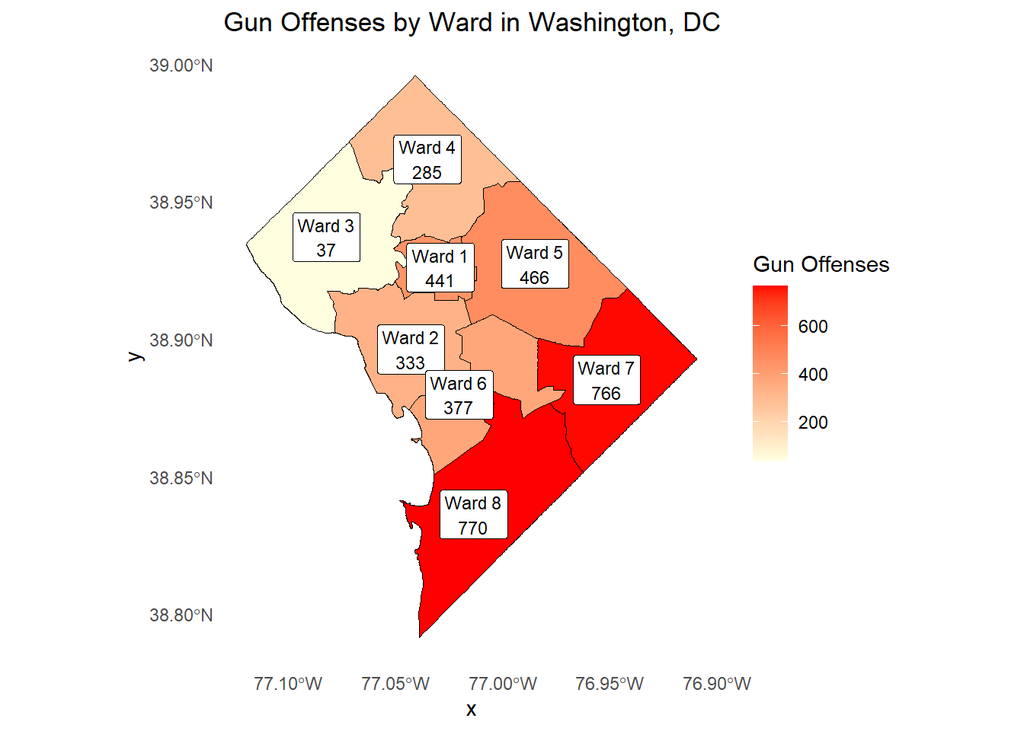

```r
# Plot the map
ggplot(dc_ward_gun_offenses) +
  geom_sf(aes(fill = gun_offense_count), color = "black") +  # Color by gun offense count
  geom_sf_label(aes(label = paste0(NAMELSAD, "\n", gun_offense_count)), size = 3) +  # Add ward labels
  scale_fill_gradient(low = "lightyellow", high = "red", na.value = "gray") +  # Color scale
  labs(title = "Gun Offenses by Ward in Washington, DC", fill = "Gun Offenses") +
  theme_minimal() +
  theme(panel.grid = element_blank())
```

```r
gun_offenses
```

```
## # A tibble: 8 × 2
##   WARD   gun_offense_count
##   <chr>              <int>
## 1 Ward 1               441
## 2 Ward 2               333
## 3 Ward 3                37
## 4 Ward 4               285
## 5 Ward 5               466
## 6 Ward 6               377
## 7 Ward 7               766
## 8 Ward 8               770
```

```r
#dc_ward_gun_offenses
#crime_data2
```

```r
# get tge boundries by districts.
dc_districts <- state_legislative_districts(state = "dc", class = 'sf')
```

# **MAP conculsion by-**

Offenses by Ward in Washington, DC (Midnight Shift & Robbery)–

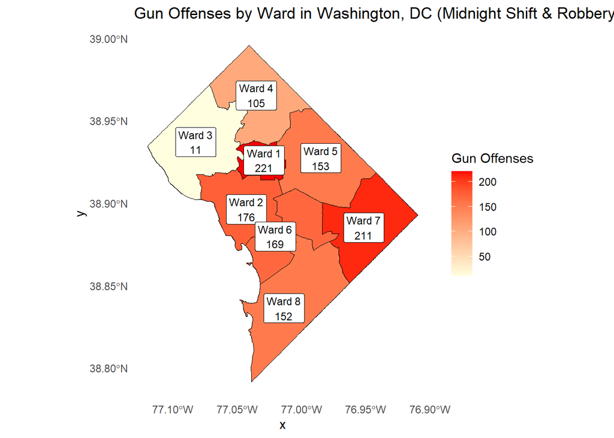

```r
# Load necessary libraries
library(tidyverse)
library(sf)
library(dplyr)
library(ggplot2)

# Filter the crime_data2 dataset for gun offenses during the midnight shift and robbery offenses
gun_offenses <- crime_data2 %>%
  filter(METHOD == "GUN", SHIFT == "MIDNIGHT", OFFENSE == "ROBBERY") %>%  # Add filters for shift and offense
  group_by(WARD) %>%
  summarize(gun_offense_count = n(), .groups = 'drop')  # Count occurrences

# Ensure the WARD column in gun_offenses is a character and match the format of NAMELSAD
gun_offenses <- gun_offenses %>%
   mutate(WARD = paste("Ward", as.character(WARD)))  # Add "Ward " prefix if needed

# Merge dc_wards with gun offense counts
dc_ward_gun_offenses <- dc_wards %>%
  left_join(gun_offenses, by = c("NAMELSAD" = "WARD"))


# Plot the map
ggplot(dc_ward_gun_offenses) +
  geom_sf(aes(fill = gun_offense_count), color = "black") +  # Color by gun offense count
  geom_sf_label(aes(label = paste0(NAMELSAD, "\n", gun_offense_count)), size = 3) +  # Add ward labels
  scale_fill_gradient(low = "lightyellow", high = "red", na.value = "gray") +  # Color scale
  labs(title = "Gun Offenses by Ward in Washington, DC (Midnight Shift & Robbery)", fill = "Gun Offenses") +
  theme_minimal() +
  theme(panel.grid = element_blank())
```

In stark contrast, Ward 3 emerges as the safest area in Washington, DC, exhibiting the least number of gun offenses. This relative security indicates effective community safety practices and law enforcement strategies that could be analyzed and potentially replicated in more troubled wards.

Discussion–

Crime Trends: Our analysis indicates that theft is the predominant type of crime in Washington, DC. Seasonal variations were evident, with significant spikes in crime during the summer months, particularly in July, likely due to increased outdoor activities and population density.

Impact of Events: We observed a rise in crime rates in October 2023, coinciding with the “Rock the Park” event. This correlation highlights the need for enhanced security measures during large public gatherings, as such events can create opportunities for theft and other offenses.

Local vs. Tourist Criminality: An important consideration is whether the individuals committing these crimes are local residents or tourists. Given DC’s appeal as a tourist destination, understanding the demographics of offenders can inform targeted crime prevention strategies.

Clusters and Wards: In our analysis, we divided Washington, DC, into clusters and wards to better understand regional crime dynamics. Notably, Ward 3 emerged as the safest area, while Wards 2 and 5 recorded significantly higher crime rates. This finding suggests that crime prevention efforts may need to be tailored to specific wards, particularly in areas experiencing elevated crime levels.

Policy Implications and Future Research: The findings underscore the need for targeted policing strategies and community engagement initiatives to address high theft rates and seasonal crime spikes. Future research should investigate the effectiveness of these strategies and explore the demographics of offenders to gain a clearer understanding of crime dynamics in Washington, DC.

Limitations: While this study provides valuable insights, it is important to acknowledge certain limitations. The analysis relies on reported crime data, which may not capture unreported incidents. Additionally, external factors such as changes in policing strategies or socio-economic conditions could influence crime rates and were not accounted for in this analysis. Our dataset also lacks information on the residency status of offenders, limiting our ability to assess whether crimes are committed by local residents or tourists. Future research should consider incorporating qualitative data to provide a more comprehensive view of the factors influencing crime.

Recommendations 1)Increase Police Surveillance: Focus on wards with high gun offense rates to deter criminal activity.

2)Establish More Police Stations: Consider placing police stations in areas identified as gun offense hotspots to improve response times and community engagement.

Analysis Summary In this analysis, we observed gun offenses related to robbery occurring at midnight in Washington, DC. Based on the data, we found significant insights regarding the distribution of these offenses across different wards:

Gun Offense Trends:

In contrast, Ward 3 was identified as the safest area with the least occurrences of gun offenses, suggesting it may have effective crime prevention measures in place.

# **conclusion for EDA**

Based on these findings, a recommendation is to increase police surveillance and allocate more resources to the identified high-risk wards and districts. Targeted patrols, community outreach, and preventative measures in these areas could potentially reduce gun-related offenses, enhancing overall public safety in Washington, DC.

```r
selected_columns <- c(
  "REPORT_DAT", "SHIFT", "METHOD", "OFFENSE", "WARD","ANC" ,
  "DISTRICT", "PSA", "X", "Y", "LATITUDE", "LONGITUDE", "Season"
)

data <- crime_data2 %>% select(all_of(selected_columns))

str(data)
```

```
## 'data.frame':    33899 obs. of  13 variables:
##  $ REPORT_DAT: Date, format: "2023-07-25" "2023-03-27" ...
##  $ SHIFT     : Factor w/ 3 levels "DAY","EVENING",..: 3 3 1 3 2 1 3 1 1 1 ...
##  $ METHOD    : chr  "OTHERS" "GUN" "OTHERS" "OTHERS" ...
##  $ OFFENSE   : chr  "ROBBERY" "ROBBERY" "THEFT/OTHER" "THEFT F/AUTO" ...
##  $ WARD      : int  1 4 2 2 1 8 6 2 2 1 ...
##  $ ANC       : chr  "1D" "4A" "2G" "2C" ...
##  $ DISTRICT  : int  3 4 3 2 3 7 1 1 2 3 ...
##  $ PSA       : int  302 401 308 207 304 701 103 101 209 302 ...
##  $ X         : num  0.369 0.394 0.468 0.365 0.434 ...
##  $ Y         : num  0.656 0.976 0.525 0.501 0.631 ...
##  $ LATITUDE  : num  0.656 0.976 0.525 0.501 0.631 ...
##  $ LONGITUDE : num  0.369 0.394 0.468 0.365 0.434 ...
##  $ Season    : chr  "Summer" "Spring" "Fall" "Spring" ...
```

check the missing values for the model.

```r
missing_summary <- sapply(data, function(x) sum(is.na(x)))
print(missing_summary)
```

```
## REPORT_DAT      SHIFT     METHOD    OFFENSE       WARD        ANC   DISTRICT
##          0          0          0          0          0          0          0
##        PSA          X          Y   LATITUDE  LONGITUDE     Season
##          0          0          0          0          0          0
```

```r
data$REPORT_DAT <- as.Date(data$REPORT_DAT)
```

```r
# Load necessary library
library(dplyr)

# Calculate the number of unique values for each column
unique_values <- sapply(data, function(col) length(unique(col)))

# Convert the result to a data frame for better readability
unique_values_df <- data.frame(
  Column = names(unique_values),
  UniqueValues = unique_values
)

# Print the unique values
print(unique_values_df)
```

```
##                Column UniqueValues
## REPORT_DAT REPORT_DAT          366
## SHIFT           SHIFT            3
## METHOD         METHOD            3
## OFFENSE       OFFENSE            9
## WARD             WARD            8
## ANC               ANC           46
## DISTRICT     DISTRICT            7
## PSA               PSA           57
## X                   X         9181
## Y                   Y         9375
## LATITUDE     LATITUDE        11400
## LONGITUDE   LONGITUDE        11402
## Season         Season            5
```

```r
data$REPORT_DAT <- as.Date(data$REPORT_DAT, format = "%Y-%m-%d")

data$Month <- month(data$REPORT_DAT)
data$Day <- day(data$REPORT_DAT)
```

as we in the EDA crime related to gun by shift most of the crime happen in the midnight followed by evenning and day . So let’s find out

MODEL BULDING

convert the data into factors

```r
crime_data
```

[output not shown]

[output cut: 23986 more lines]

```r
crime_data$REPORT_DAT <- as.Date(crime_data$REPORT_DAT)

data$ANC <- as.factor(data$ANC)
data$Season <- as.factor(data$Season)
data$SHIFT <- as.factor(data$SHIFT)
data$METHOD <- as.factor(data$METHOD)
data$OFFENSE <- as.factor(data$OFFENSE)
data$WARD <- as.factor(data$WARD)
data$DISTRICT <- as.factor(data$DISTRICT)
data$PSA <- as.factor(data$PSA)
```

# **Lebal Encoding**

all our variables are in the categorical formate so we are have to convert it in to levele according to the

```r
# Label Encoding for ordinal variables (e.g., SHIFT, ANC, PSA)
data$SHIFT <- as.integer(factor(data$SHIFT))   # Label Encoding for SHIFT
data$ANC <- as.integer(factor(data$ANC))       # Label Encoding for ANC
data$PSA <- as.integer(factor(data$PSA))       # Label Encoding for PSA

# One-Hot Encoding for nominal variables (e.g., METHOD, OFFENSE, WARD, DISTRICT, SEASON)
data <- cbind(data, model.matrix(~ METHOD + OFFENSE + WARD + DISTRICT + Season - 1, data = data))

# Remove the original categorical columns after one-hot encoding
data <- data[, !names(data) %in% c('SHIFT', 'METHOD', 'OFFENSE', 'WARD', 'DISTRICT', 'Season')]

# Check the updated data structure
str(data)
```

```
## 'data.frame':    33899 obs. of  37 variables:
##  $ REPORT_DAT                       : Date, format: "2023-07-25" "2023-03-27" ...
##  $ ANC                              : int  4 20 12 8 5 41 34 8 8 4 ...
##  $ PSA                              : int  19 26 25 15 21 50 3 1 17 19 ...
##  $ X                                : num  0.369 0.394 0.468 0.365 0.434 ...
##  $ Y                                : num  0.656 0.976 0.525 0.501 0.631 ...
##  $ LATITUDE                         : num  0.656 0.976 0.525 0.501 0.631 ...
##  $ LONGITUDE                        : num  0.369 0.394 0.468 0.365 0.434 ...
##  $ Month                            : num  7 3 11 4 4 9 9 8 6 8 ...
##  $ Day                              : int  25 27 15 10 11 22 24 11 4 9 ...
##  $ METHODGUN                        : num  0 1 0 0 0 0 0 0 0 0 ...
##  $ METHODKNIFE                      : num  0 0 0 0 0 0 0 0 0 0 ...
##  $ METHODOTHERS                     : num  1 0 1 1 1 1 1 1 1 1 ...
##  $ OFFENSEASSAULT W/DANGEROUS WEAPON: num  0 0 0 0 0 0 0 0 0 0 ...
##  $ OFFENSEBURGLARY                  : num  0 0 0 0 0 0 0 0 0 0 ...
```

[output cut: 23 more lines]

```r
head(data)
```

```
##   REPORT_DAT ANC PSA     X     Y LATITUDE LONGITUDE Month Day METHODGUN
## 1 2023-07-25   4  19 0.369 0.656    0.656     0.369     7  25         0
## 2 2023-03-27  20  26 0.394 0.976    0.976     0.394     3  27         1
## 3 2023-11-15  12  25 0.468 0.525    0.525     0.468    11  15         0
## 4 2023-04-10   8  15 0.365 0.501    0.501     0.365     4  10         0
## 5 2023-04-11   5  21 0.434 0.631    0.631     0.434     4  11         0
## 6 2023-09-22  41  50 0.611 0.293    0.293     0.611     9  22         0
##   METHODKNIFE METHODOTHERS OFFENSEASSAULT W/DANGEROUS WEAPON OFFENSEBURGLARY
## 1           0            1                                 0               0
## 2           0            0                                 0               0
## 3           0            1                                 0               0
## 4           0            1                                 0               0
## 5           0            1                                 0               0
## 6           0            1                                 0               0
##   OFFENSEHOMICIDE OFFENSEMOTOR VEHICLE THEFT OFFENSEROBBERY OFFENSESEX ABUSE
```

[output cut: 27 more lines]

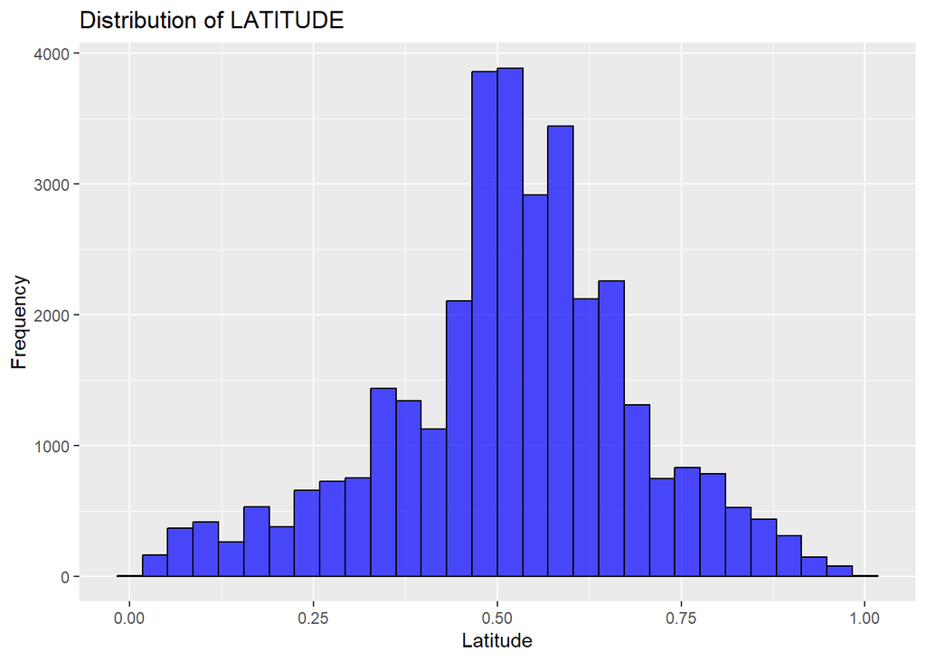

```r
library(ggplot2)

# Plot distribution of LATITUDE and LONGITUDE
ggplot(data, aes(x=LATITUDE)) +
  geom_histogram(bins=30, fill="blue", color="black", alpha=0.7) +
  labs(title="Distribution of LATITUDE", x="Latitude", y="Frequency")
```

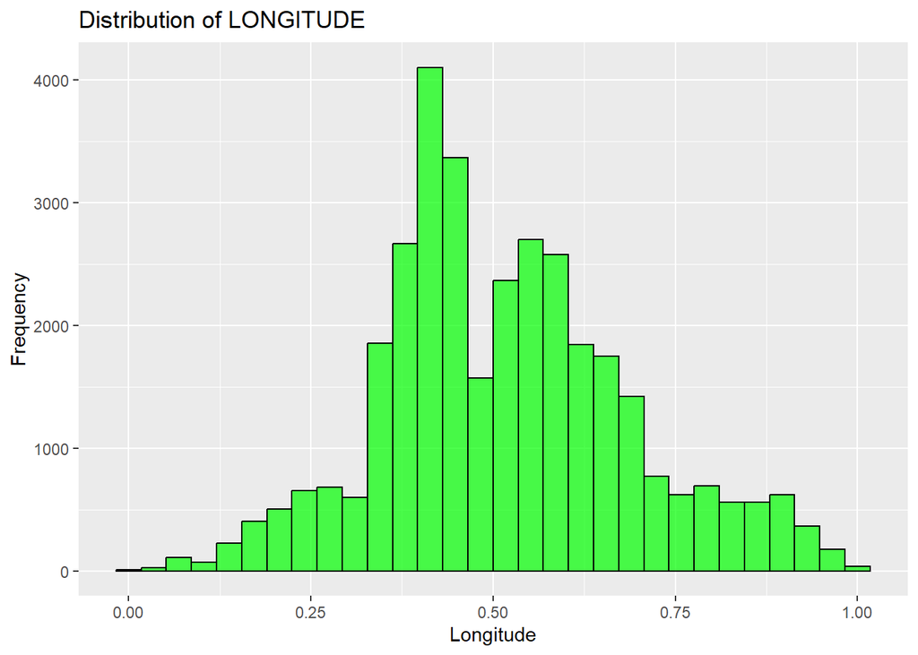

```r
ggplot(data, aes(x=LONGITUDE)) +
  geom_histogram(bins=30, fill="green", color="black", alpha=0.7) +
  labs(title="Distribution of LONGITUDE", x="Longitude", y="Frequency")
```

corr

[figure not shown]

```r
# Compute correlation matrix
cor_matrix <- cor(data[, sapply(data, is.numeric)])

# Plot correlation heatmap
library(corrplot)
corrplot(cor_matrix, method="circle", type="upper", order="hclust",
         tl.col="black", tl.srt=65)
```

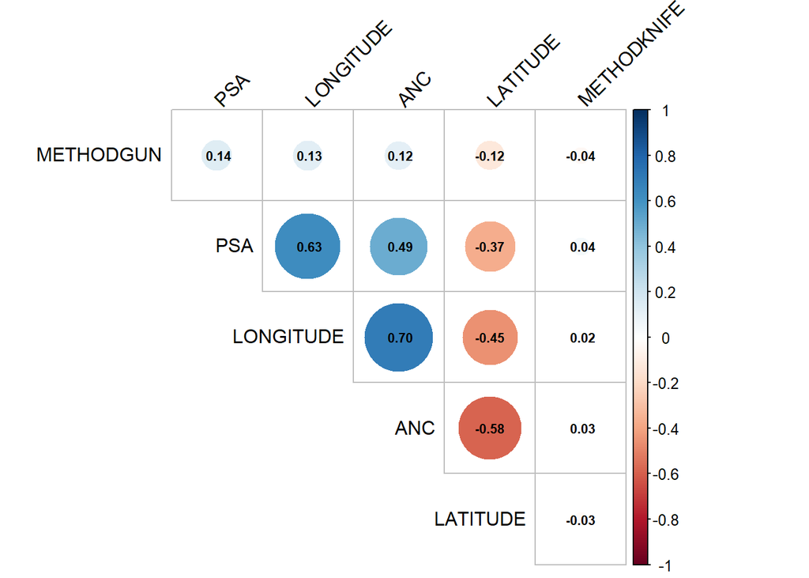

```r
selected_vars <- data[, c("LATITUDE", "LONGITUDE", "ANC", "PSA", "METHODGUN", "METHODKNIFE")]

cor_matrix <- cor(selected_vars)

library(corrplot)
corrplot(cor_matrix, method="circle", type="upper", order="hclust",
         tl.col="black", tl.srt=45, diag=FALSE, addCoef.col="black", number.cex=0.7)
```

```r
png("correlation_plot.png", width=1500, height=1200, res=150)
corrplot(cor_matrix, method="circle", type="upper", order="hclust",
         tl.col="black", tl.srt=45, diag=FALSE, addCoef.col="black", number.cex=0.7)
dev.off()
```

```r
cor_matrix <- cor(data[, sapply(data, is.numeric)])

print(cor_matrix)
```

```
##                                        ANC      PSA        X        Y LATITUDE
## ANC                                1.00000  0.49190  0.69593 -0.58167 -0.58167
## PSA                                0.49190  1.00000  0.62676 -0.36923 -0.36923
## X                                  0.69593  0.62676  1.00000 -0.45271 -0.45270
## Y                                 -0.58167 -0.36923 -0.45271  1.00000  1.00000
## LATITUDE                          -0.58167 -0.36923 -0.45270  1.00000  1.00000
## LONGITUDE                          0.69590  0.62671  1.00000 -0.45278 -0.45277
## Month                             -0.03939 -0.04824 -0.05075  0.02857  0.02857
## Day                                0.00390  0.00382  0.00566 -0.00650 -0.00650
## METHODGUN                          0.11958  0.13786  0.12865 -0.12394 -0.12394
## METHODKNIFE                        0.02577  0.04435  0.02325 -0.02925 -0.02925
## METHODOTHERS                      -0.12254 -0.14656 -0.13022  0.12793  0.12793
## OFFENSEASSAULT W/DANGEROUS WEAPON  0.10803  0.14873  0.09961 -0.11888 -0.11889
## OFFENSEBURGLARY                    0.01464  0.02053  0.01638 -0.00931 -0.00931
## OFFENSEHOMICIDE                    0.05657  0.06410  0.04690 -0.06267 -0.06267
## OFFENSEMOTOR VEHICLE THEFT         0.16224  0.11957  0.15865 -0.06377 -0.06376
## OFFENSEROBBERY                     0.05509  0.06126  0.07753 -0.05237 -0.05237
## OFFENSESEX ABUSE                   0.02638  0.01155  0.01722 -0.02520 -0.02520
## OFFENSETHEFT F/AUTO               -0.08727 -0.07006 -0.08033  0.10995  0.10994
## OFFENSETHEFT/OTHER                -0.15622 -0.15771 -0.16711  0.05790  0.05790
## WARD2                             -0.45334 -0.31326 -0.35670 -0.01965 -0.01966
## WARD3                             -0.12558 -0.27269 -0.46267  0.26300  0.26287
## WARD4                             -0.04451  0.00990 -0.15419  0.52223  0.52227
## WARD5                              0.13513  0.24046  0.22759  0.18380  0.18387
## WARD6                              0.28143 -0.42137  0.05955 -0.18570 -0.18564
## WARD7                              0.40186  0.39329  0.66822 -0.26148 -0.26158
## WARD8                              0.50186  0.45903  0.17705 -0.65377 -0.65375
## DISTRICT2                         -0.38632 -0.40021 -0.57876  0.16278  0.16266
## DISTRICT3                         -0.59237 -0.19704 -0.29876  0.18197  0.18200
## DISTRICT4                         -0.11291  0.05527 -0.13978  0.55122  0.55127
## DISTRICT5                          0.18864  0.29948  0.25553  0.10003  0.10009
## DISTRICT6                          0.39959  0.45274  0.66712 -0.28912 -0.28923
## DISTRICT7                          0.42942  0.52676  0.15149 -0.62902 -0.62900
## SeasonSpring                       0.02926  0.03322  0.03531 -0.02012 -0.02012
## SeasonSummer                       0.00731 -0.00200  0.00712 -0.01301 -0.01301
## SeasonUnknown                     -0.00163  0.00380  0.00303 -0.00358 -0.00358
## SeasonWinter                      -0.00140  0.01553  0.00801  0.00665  0.00665
##                                   LONGITUDE    Month       Day METHODGUN
## ANC                                 0.69590 -0.03939  3.90e-03   0.11958
## PSA                                 0.62671 -0.04824  3.82e-03   0.13786
```

[output cut: 389 more lines]

```
## WARD4                                -0.024158     -0.002439      0.02162
## WARD5                                 0.016435     -0.003406     -0.01168
## WARD6                                 0.016939     -0.002909     -0.01650
## WARD7                                -0.005976      0.008278      0.01662
## WARD8                                 0.003835     -0.002723     -0.00295
## DISTRICT2                            -0.019419     -0.003416     -0.00254
## DISTRICT3                             0.008236      0.005912     -0.00149
## DISTRICT4                            -0.022762     -0.002944      0.01659
## DISTRICT5                             0.024424     -0.003419     -0.00939
## DISTRICT6                            -0.010969      0.008568      0.01655
## DISTRICT7                             0.000578     -0.002342      0.00181
## SeasonSpring                         -0.354138     -0.004298     -0.30185
## SeasonSummer                          1.000000     -0.004861     -0.34141
## SeasonUnknown                        -0.004861      1.000000     -0.00414
## SeasonWinter                         -0.341409     -0.004144      1.00000
```

feature selection from the above we have selected the relative features for our models.

```r
head(data)
```

```
##   REPORT_DAT ANC PSA     X     Y LATITUDE LONGITUDE Month Day METHODGUN
## 1 2023-07-25   4  19 0.369 0.656    0.656     0.369     7  25         0
## 2 2023-03-27  20  26 0.394 0.976    0.976     0.394     3  27         1
## 3 2023-11-15  12  25 0.468 0.525    0.525     0.468    11  15         0
## 4 2023-04-10   8  15 0.365 0.501    0.501     0.365     4  10         0
## 5 2023-04-11   5  21 0.434 0.631    0.631     0.434     4  11         0
## 6 2023-09-22  41  50 0.611 0.293    0.293     0.611     9  22         0
##   METHODKNIFE METHODOTHERS OFFENSEASSAULT W/DANGEROUS WEAPON OFFENSEBURGLARY
## 1           0            1                                 0               0
## 2           0            0                                 0               0
## 3           0            1                                 0               0
## 4           0            1                                 0               0
## 5           0            1                                 0               0
## 6           0            1                                 0               0
##   OFFENSEHOMICIDE OFFENSEMOTOR VEHICLE THEFT OFFENSEROBBERY OFFENSESEX ABUSE
```

[output cut: 27 more lines]

from the corr plot we selected the REPORT_DAT Month Day ANC`,`PSA`,`X`,`Y`,`LATITUDE`,`LONGITUDE `OFFENSEASSAULT W/DANGEROUS WEAPON`, `OFFENSEMOTOR VEHICLE THEFT`, `OFFENSEROBBERY`, `WARD2`, `WARD3`, `WARD5`, `WARD6`, `WARD7`,`WARD8`,`SeasonSpring`,`SeasonSummer`,`SeasonWinter`,`METHODGUN for models

beacume , we tried by using all the variables model is not showing accuracy more than 53% . so that model will be regards as null model . so we will just focus on relative variables

```r
# Load necessary libraries
library(dplyr)
str(data)
```

```
## 'data.frame':    33899 obs. of  37 variables:
##  $ REPORT_DAT                       : Date, format: "2023-07-25" "2023-03-27" ...
##  $ ANC                              : int  4 20 12 8 5 41 34 8 8 4 ...
##  $ PSA                              : int  19 26 25 15 21 50 3 1 17 19 ...
##  $ X                                : num  0.369 0.394 0.468 0.365 0.434 ...
##  $ Y                                : num  0.656 0.976 0.525 0.501 0.631 ...
##  $ LATITUDE                         : num  0.656 0.976 0.525 0.501 0.631 ...
##  $ LONGITUDE                        : num  0.369 0.394 0.468 0.365 0.434 ...
##  $ Month                            : num  7 3 11 4 4 9 9 8 6 8 ...
##  $ Day                              : int  25 27 15 10 11 22 24 11 4 9 ...
##  $ METHODGUN                        : num  0 1 0 0 0 0 0 0 0 0 ...
##  $ METHODKNIFE                      : num  0 0 0 0 0 0 0 0 0 0 ...
##  $ METHODOTHERS                     : num  1 0 1 1 1 1 1 1 1 1 ...
##  $ OFFENSEASSAULT W/DANGEROUS WEAPON: num  0 0 0 0 0 0 0 0 0 0 ...
##  $ OFFENSEBURGLARY                  : num  0 0 0 0 0 0 0 0 0 0 ...
```

[output cut: 23 more lines]

```r
# Select relevant features for modeling from the 'data' dataset
selected_features <- data %>%
  select( `REPORT_DAT`,`Month`,`Day`, `ANC`, `PSA`, `X`, `Y`, `LATITUDE`, `LONGITUDE`,
         `OFFENSEASSAULT W/DANGEROUS WEAPON`,
         `OFFENSEMOTOR VEHICLE THEFT`,
         `OFFENSEROBBERY`,
         `WARD2`, `WARD3`, `WARD5`, `WARD6`, `WARD7`,`WARD8`,`SeasonSpring`,`SeasonSummer`,`SeasonWinter`,
         `METHODGUN`)

# Remove rows with missing values
data_selected <- na.omit(selected_features)

# Display the first few rows of the selected features DataFrame
head(data_selected)
```

```
##   REPORT_DAT Month Day ANC PSA     X     Y LATITUDE LONGITUDE
## 1 2023-07-25     7  25   4  19 0.369 0.656    0.656     0.369
## 2 2023-03-27     3  27  20  26 0.394 0.976    0.976     0.394
## 3 2023-11-15    11  15  12  25 0.468 0.525    0.525     0.468
## 4 2023-04-10     4  10   8  15 0.365 0.501    0.501     0.365
## 5 2023-04-11     4  11   5  21 0.434 0.631    0.631     0.434
## 6 2023-09-22     9  22  41  50 0.611 0.293    0.293     0.611
##   OFFENSEASSAULT W/DANGEROUS WEAPON OFFENSEMOTOR VEHICLE THEFT OFFENSEROBBERY
## 1                                 0                          0              1
## 2                                 0                          0              1
## 3                                 0                          0              0
## 4                                 0                          0              0
## 5                                 0                          1              0
## 6                                 0                          0              1
##   WARD2 WARD3 WARD5 WARD6 WARD7 WARD8 SeasonSpring SeasonSummer SeasonWinter
## 1     0     0     0     0     0     0            0            1            0
## 2     0     0     0     0     0     0            1            0            0
## 3     1     0     0     0     0     0            0            0            0
## 4     1     0     0     0     0     0            1            0            0
## 5     0     0     0     0     0     0            1            0            0
## 6     0     0     0     0     0     1            0            0            0
##   METHODGUN
## 1         0
## 2         1
## 3         0
## 4         0
## 5         0
## 6         0
```

```r
# Optionally, save the selected features dataset to a new CSV
write.csv(data_selected, "data_selected.csv", row.names = FALSE)

str(data_selected)
```

```
## 'data.frame':    33899 obs. of  22 variables:
##  $ REPORT_DAT                       : Date, format: "2023-07-25" "2023-03-27" ...
##  $ Month                            : num  7 3 11 4 4 9 9 8 6 8 ...
##  $ Day                              : int  25 27 15 10 11 22 24 11 4 9 ...
##  $ ANC                              : int  4 20 12 8 5 41 34 8 8 4 ...
##  $ PSA                              : int  19 26 25 15 21 50 3 1 17 19 ...
##  $ X                                : num  0.369 0.394 0.468 0.365 0.434 ...
##  $ Y                                : num  0.656 0.976 0.525 0.501 0.631 ...
##  $ LATITUDE                         : num  0.656 0.976 0.525 0.501 0.631 ...
##  $ LONGITUDE                        : num  0.369 0.394 0.468 0.365 0.434 ...
##  $ OFFENSEASSAULT W/DANGEROUS WEAPON: num  0 0 0 0 0 0 0 0 0 0 ...
##  $ OFFENSEMOTOR VEHICLE THEFT       : num  0 0 0 0 1 0 0 0 0 1 ...
##  $ OFFENSEROBBERY                   : num  1 1 0 0 0 1 0 0 0 0 ...
##  $ WARD2                            : num  0 0 1 1 0 0 0 1 1 0 ...
##  $ WARD3                            : num  0 0 0 0 0 0 0 0 0 0 ...
##  $ WARD5                            : num  0 0 0 0 0 0 0 0 0 0 ...
##  $ WARD6                            : num  0 0 0 0 0 0 1 0 0 0 ...
##  $ WARD7                            : num  0 0 0 0 0 0 0 0 0 0 ...
##  $ WARD8                            : num  0 0 0 0 0 1 0 0 0 0 ...
##  $ SeasonSpring                     : num  0 1 0 1 1 0 0 0 0 0 ...
##  $ SeasonSummer                     : num  1 0 0 0 0 0 0 1 1 1 ...
##  $ SeasonWinter                     : num  0 0 0 0 0 0 0 0 0 0 ...
##  $ METHODGUN                        : num  0 1 0 0 0 0 0 0 0 0 ...
```

# **GLM Model- Offence of motor Vehicle Theft**

we first created the GLM model for the theft regarding the motor vehicle . the target varible in this model is OFFENSEMOTOR_VEHICLE_THEFT.

```r
# Renaming columns with spaces or special characters
colnames(data_selected) <- gsub(" ", "_", colnames(data_selected))
colnames(data_selected) <- gsub("/", "_", colnames(data_selected))

# Check the new column names
colnames(data_selected)
```

```
##  [1] "REPORT_DAT"                        "Month"
##  [3] "Day"                               "ANC"
##  [5] "PSA"                               "X"
##  [7] "Y"                                 "LATITUDE"
##  [9] "LONGITUDE"                         "OFFENSEASSAULT_W_DANGEROUS_WEAPON"
## [11] "OFFENSEMOTOR_VEHICLE_THEFT"        "OFFENSEROBBERY"
## [13] "WARD2"                             "WARD3"
## [15] "WARD5"                             "WARD6"
## [17] "WARD7"                             "WARD8"
## [19] "SeasonSpring"                      "SeasonSummer"
## [21] "SeasonWinter"                      "METHODGUN"
```

```r
nrow(data_selected)
```

```
## [1] 33899
```

```r
library(ROSE)
balanced_data <- ovun.sample(OFFENSEMOTOR_VEHICLE_THEFT ~ .,
                             data = data_selected,
                             method = "over",
                             N = nrow(data_selected))$data  # Match the sample size


# Check the structure of the balanced data
str(balanced_data)
```

```
## 'data.frame':    33899 obs. of  22 variables:
##  $ REPORT_DAT                       : Date, format: "2023-07-25" "2023-03-27" ...
##  $ Month                            : num  7 3 11 4 9 9 8 6 12 7 ...
##  $ Day                              : int  25 27 15 10 22 24 11 4 24 1 ...
##  $ ANC                              : int  4 20 12 8 41 34 8 8 12 32 ...
##  $ PSA                              : int  19 26 25 15 50 3 1 17 25 7 ...
##  $ X                                : num  0.369 0.394 0.468 0.365 0.611 ...
##  $ Y                                : num  0.656 0.976 0.525 0.501 0.293 ...
##  $ LATITUDE                         : num  0.656 0.976 0.525 0.501 0.293 ...
##  $ LONGITUDE                        : num  0.369 0.394 0.468 0.365 0.611 ...
##  $ OFFENSEASSAULT_W_DANGEROUS_WEAPON: num  0 0 0 0 0 0 0 0 0 0 ...
##  $ OFFENSEMOTOR_VEHICLE_THEFT       : num  0 0 0 0 0 0 0 0 0 0 ...
##  $ OFFENSEROBBERY                   : num  1 1 0 0 1 0 0 0 0 0 ...
##  $ WARD2                            : num  0 0 1 1 0 0 1 1 1 0 ...
##  $ WARD3                            : num  0 0 0 0 0 0 0 0 0 0 ...
##  $ WARD5                            : num  0 0 0 0 0 0 0 0 0 0 ...
##  $ WARD6                            : num  0 0 0 0 0 1 0 0 0 1 ...
##  $ WARD7                            : num  0 0 0 0 0 0 0 0 0 0 ...
##  $ WARD8                            : num  0 0 0 0 1 0 0 0 0 0 ...
##  $ SeasonSpring                     : num  0 1 0 1 0 0 0 0 0 0 ...
##  $ SeasonSummer                     : num  1 0 0 0 0 0 1 1 0 1 ...
##  $ SeasonWinter                     : num  0 0 0 0 0 0 0 0 1 0 ...
##  $ METHODGUN                        : num  0 1 0 0 0 0 0 0 0 0 ...
```

```r
table(balanced_data$OFFENSEMOTOR_VEHICLE_THEFT)
```

```
##
##     0     1
## 27163  6736
```

```r
# Rebuild the logistic regression model with the balanced data
model_balanced <- glm(OFFENSEMOTOR_VEHICLE_THEFT ~ ANC + PSA + X + Y + LATITUDE + LONGITUDE +
                     WARD2 + WARD3 + WARD5 + WARD6, data = balanced_data, family = binomial)

# Model summary
summary(model_balanced)
```

```
##
## Call:
## glm(formula = OFFENSEMOTOR_VEHICLE_THEFT ~ ANC + PSA + X + Y +
##     LATITUDE + LONGITUDE + WARD2 + WARD3 + WARD5 + WARD6, family = binomial,
##     data = balanced_data)
##
## Coefficients:
##              Estimate Std. Error z value Pr(>|z|)
## (Intercept) -2.62e+00   1.56e-01  -16.82  < 2e-16 ***
## ANC          2.36e-02   2.03e-03   11.64  < 2e-16 ***
## PSA          1.48e-03   1.61e-03    0.92   0.3557
## X           -7.59e+01   4.00e+02   -0.19   0.8495
## Y           -4.48e+02   6.36e+02   -0.70   0.4814
## LATITUDE     4.48e+02   6.36e+02    0.71   0.4808
## LONGITUDE    7.65e+01   4.00e+02    0.19   0.8483
## WARD2       -4.07e-01   6.45e-02   -6.30  2.9e-10 ***
## WARD3       -9.18e-01   1.36e-01   -6.73  1.7e-11 ***
## WARD5        1.46e-01   5.00e-02    2.93   0.0034 **
## WARD6       -9.12e-02   6.39e-02   -1.43   0.1537
## ---
## Signif. codes:  0 '***' 0.001 '**' 0.01 '*' 0.05 '.' 0.1 ' ' 1
##
## (Dispersion parameter for binomial family taken to be 1)
##
##     Null deviance: 33804  on 33898  degrees of freedom
## Residual deviance: 32482  on 33888  degrees of freedom
## AIC: 32504
##
## Number of Fisher Scoring iterations: 5
```

```r
# Get predicted probabilities
pred_prob <- predict(model_balanced, type = "response", newdata = balanced_data)

# Convert probabilities to predicted classes (0 or 1) using a threshold of 0.5
pred_class <- ifelse(pred_prob > 0.5, 1, 0)



# Calculate Accuracy
accuracy <- mean(pred_class == balanced_data$OFFENSEMOTOR_VEHICLE_THEFT)
accuracy
```

```
## [1] 0.801
```

```r
library(pROC)

# Compute the ROC curve and AUC
roc_curve <- roc(balanced_data$OFFENSEMOTOR_VEHICLE_THEFT, pred_prob)
auc(roc_curve)
```

```
## Area under the curve: 0.633
```

```r
# Renaming columns with spaces or special characters
colnames(data_selected) <- gsub(" ", "_", colnames(data_selected))  # Replace spaces with underscores
colnames(data_selected) <- gsub("/", "_", colnames(data_selected))  # Replace '/' with underscores

# Check the new column names
colnames(data_selected)
```

```
##  [1] "REPORT_DAT"                        "Month"
##  [3] "Day"                               "ANC"
##  [5] "PSA"                               "X"
##  [7] "Y"                                 "LATITUDE"
##  [9] "LONGITUDE"                         "OFFENSEASSAULT_W_DANGEROUS_WEAPON"
## [11] "OFFENSEMOTOR_VEHICLE_THEFT"        "OFFENSEROBBERY"
## [13] "WARD2"                             "WARD3"
## [15] "WARD5"                             "WARD6"
## [17] "WARD7"                             "WARD8"
## [19] "SeasonSpring"                      "SeasonSummer"
## [21] "SeasonWinter"                      "METHODGUN"
```

```r
# Check the number of rows in the dataset
nrow(data_selected)
```

```
## [1] 33899
```

```r
# Load the ROSE package for oversampling
library(ROSE)

# Balance the dataset using oversampling
balanced_data <- ovun.sample(OFFENSEMOTOR_VEHICLE_THEFT ~ .,
                             data = data_selected,
                             method = "over",
                             N = nrow(data_selected))$data  # Match the sample size

# Check the structure of the balanced data
str(balanced_data)
```

```
## 'data.frame':    33899 obs. of  22 variables:
##  $ REPORT_DAT                       : Date, format: "2023-07-25" "2023-03-27" ...
##  $ Month                            : num  7 3 11 4 9 9 8 6 12 7 ...
##  $ Day                              : int  25 27 15 10 22 24 11 4 24 1 ...
##  $ ANC                              : int  4 20 12 8 41 34 8 8 12 32 ...
##  $ PSA                              : int  19 26 25 15 50 3 1 17 25 7 ...
##  $ X                                : num  0.369 0.394 0.468 0.365 0.611 ...
##  $ Y                                : num  0.656 0.976 0.525 0.501 0.293 ...
##  $ LATITUDE                         : num  0.656 0.976 0.525 0.501 0.293 ...
##  $ LONGITUDE                        : num  0.369 0.394 0.468 0.365 0.611 ...
##  $ OFFENSEASSAULT_W_DANGEROUS_WEAPON: num  0 0 0 0 0 0 0 0 0 0 ...
##  $ OFFENSEMOTOR_VEHICLE_THEFT       : num  0 0 0 0 0 0 0 0 0 0 ...
##  $ OFFENSEROBBERY                   : num  1 1 0 0 1 0 0 0 0 0 ...
##  $ WARD2                            : num  0 0 1 1 0 0 1 1 1 0 ...
##  $ WARD3                            : num  0 0 0 0 0 0 0 0 0 0 ...
##  $ WARD5                            : num  0 0 0 0 0 0 0 0 0 0 ...
##  $ WARD6                            : num  0 0 0 0 0 1 0 0 0 1 ...
##  $ WARD7                            : num  0 0 0 0 0 0 0 0 0 0 ...
##  $ WARD8                            : num  0 0 0 0 1 0 0 0 0 0 ...
##  $ SeasonSpring                     : num  0 1 0 1 0 0 0 0 0 0 ...
##  $ SeasonSummer                     : num  1 0 0 0 0 0 1 1 0 1 ...
##  $ SeasonWinter                     : num  0 0 0 0 0 0 0 0 1 0 ...
##  $ METHODGUN                        : num  0 1 0 0 0 0 0 0 0 0 ...
```

```r
# Check the distribution of the target variable in the balanced dataset
table(balanced_data$OFFENSEMOTOR_VEHICLE_THEFT)
```

```
##
##     0     1
## 27163  6736
```

```r
# Build the logistic regression model with the balanced data
model_balanced <- glm(OFFENSEMOTOR_VEHICLE_THEFT ~ ANC + PSA + X + Y + LATITUDE + LONGITUDE +
                     WARD2 + WARD3 + WARD5 + WARD6, data = balanced_data, family = binomial)

# Model summary
summary(model_balanced)
```

```
##
## Call:
## glm(formula = OFFENSEMOTOR_VEHICLE_THEFT ~ ANC + PSA + X + Y +
##     LATITUDE + LONGITUDE + WARD2 + WARD3 + WARD5 + WARD6, family = binomial,
##     data = balanced_data)
##
## Coefficients:
##              Estimate Std. Error z value Pr(>|z|)
## (Intercept) -2.73e+00   1.55e-01  -17.54  < 2e-16 ***
## ANC          2.60e-02   2.05e-03   12.68  < 2e-16 ***
## PSA          3.75e-03   1.61e-03    2.33    0.020 *
## X           -5.76e+02   3.96e+02   -1.46    0.145
## Y            6.55e+02   6.15e+02    1.06    0.287
## LATITUDE    -6.54e+02   6.15e+02   -1.06    0.288
## LONGITUDE    5.76e+02   3.96e+02    1.46    0.145
## WARD2       -3.32e-01   6.40e-02   -5.19  2.1e-07 ***
## WARD3       -7.64e-01   1.29e-01   -5.92  3.3e-09 ***
## WARD5        1.64e-01   4.99e-02    3.29    0.001 **
## WARD6        4.66e-02   6.36e-02    0.73    0.464
## ---
## Signif. codes:  0 '***' 0.001 '**' 0.01 '*' 0.05 '.' 0.1 ' ' 1
##
## (Dispersion parameter for binomial family taken to be 1)
##
##     Null deviance: 33804  on 33898  degrees of freedom
## Residual deviance: 32600  on 33888  degrees of freedom
## AIC: 32622
##
## Number of Fisher Scoring iterations: 4
```

```r
# Get predicted probabilities
pred_prob <- predict(model_balanced, type = "response", newdata = balanced_data)

# Convert probabilities to predicted classes (0 or 1) using a threshold of 0.5
pred_class <- ifelse(pred_prob > 0.5, 1, 0)

# Calculate Accuracy
accuracy <- mean(pred_class == balanced_data$OFFENSEMOTOR_VEHICLE_THEFT)
print(paste("Accuracy: ", round(accuracy, 3)))
```

```
## [1] "Accuracy:  0.801"
```

```r
# Load the pROC package for ROC curve and AUC
library(pROC)

# Compute the ROC curve
roc_curve <- roc(balanced_data$OFFENSEMOTOR_VEHICLE_THEFT, pred_prob)

# Compute AUC (Area Under the Curve)
auc_value <- auc(roc_curve)
print(paste("AUC: ", round(auc_value, 3)))
```

```
## [1] "AUC:  0.627"
```

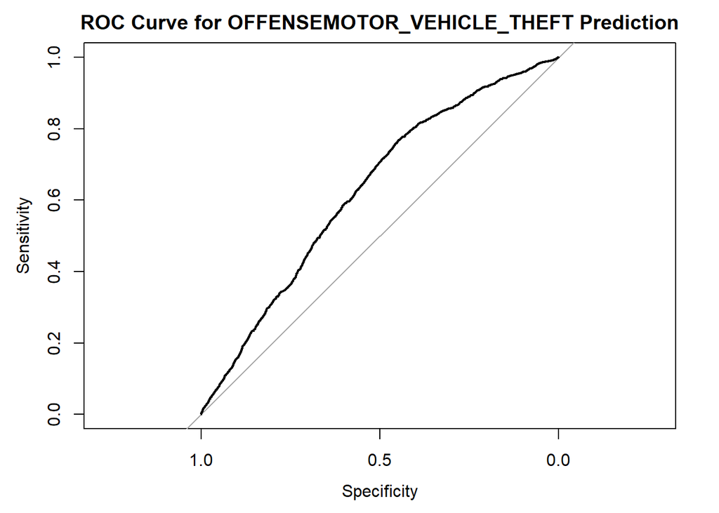

```r
# Plot the ROC curve
plot(roc_curve, main = "ROC Curve for OFFENSEMOTOR_VEHICLE_THEFT Prediction")
```

as GLM give accurecy about 80% with Area under curve 63% .

```r
# Get unique value

# Display unique values for each column
library(dplyr)
library(lubridate)

# Convert REPORT_DAT to Date
data_selected$REPORT_DAT <- as.Date(data_selected$REPORT_DAT, format = "%Y-%m-%d")
# Check for missing data
      sum(is.na(data_selected))
```

```
## [1] 0
```

```r
# Drop missing data rows for simplicity
data_selected <- data_selected %>% drop_na()

str(data_selected)
```

```
## 'data.frame':    33899 obs. of  22 variables:
##  $ REPORT_DAT                       : Date, format: "2023-07-25" "2023-03-27" ...
##  $ Month                            : num  7 3 11 4 4 9 9 8 6 8 ...
##  $ Day                              : int  25 27 15 10 11 22 24 11 4 9 ...
##  $ ANC                              : int  4 20 12 8 5 41 34 8 8 4 ...
##  $ PSA                              : int  19 26 25 15 21 50 3 1 17 19 ...
##  $ X                                : num  0.369 0.394 0.468 0.365 0.434 ...
##  $ Y                                : num  0.656 0.976 0.525 0.501 0.631 ...
##  $ LATITUDE                         : num  0.656 0.976 0.525 0.501 0.631 ...
##  $ LONGITUDE                        : num  0.369 0.394 0.468 0.365 0.434 ...
##  $ OFFENSEASSAULT_W_DANGEROUS_WEAPON: num  0 0 0 0 0 0 0 0 0 0 ...
##  $ OFFENSEMOTOR_VEHICLE_THEFT       : num  0 0 0 0 1 0 0 0 0 1 ...
##  $ OFFENSEROBBERY                   : num  1 1 0 0 0 1 0 0 0 0 ...
##  $ WARD2                            : num  0 0 1 1 0 0 0 1 1 0 ...
##  $ WARD3                            : num  0 0 0 0 0 0 0 0 0 0 ...
##  $ WARD5                            : num  0 0 0 0 0 0 0 0 0 0 ...
##  $ WARD6                            : num  0 0 0 0 0 0 1 0 0 0 ...
##  $ WARD7                            : num  0 0 0 0 0 0 0 0 0 0 ...
##  $ WARD8                            : num  0 0 0 0 0 1 0 0 0 0 ...
##  $ SeasonSpring                     : num  0 1 0 1 1 0 0 0 0 0 ...
##  $ SeasonSummer                     : num  1 0 0 0 0 0 0 1 1 1 ...
##  $ SeasonWinter                     : num  0 0 0 0 0 0 0 0 0 0 ...
##  $ METHODGUN                        : num  0 1 0 0 0 0 0 0 0 0 ...
```

# **model Method_GUN Random forest**

```r
# Load necessary libraries
library(caret)
library(pROC)
library(randomForest)
library(ROSE)  # For oversampling if needed

# Set seed for reproducibility
set.seed(123)

# Check if METHODGUN is a factor, convert if necessary
data_selected$METHODGUN <- as.factor(data_selected$METHODGUN)

# Handle imbalance by oversampling (if necessary)
balanced_data <- ovun.sample(METHODGUN ~ ., data = data_selected, method = "over", N = nrow(data_selected))$data

# Split the data into training and test sets (80-20 split)
train_index <- createDataPartition(balanced_data$METHODGUN, p = 0.8, list = FALSE)
train_data <- balanced_data[train_index, ]
test_data <- balanced_data[-train_index, ]

# Train Random Forest model
rf_model <- randomForest(
  METHODGUN ~ .,
  data = train_data,
  ntree = 100,
  mtry = sqrt(ncol(train_data) - 1),
  importance = TRUE
)

# Predict on training data
train_predictions <- predict(rf_model, train_data, type = "prob")[,2]
train_classes <- predict(rf_model, train_data)

# Predict on test data
test_predictions <- predict(rf_model, test_data, type = "prob")[,2]
test_classes <- predict(rf_model, test_data)

# Calculate AUC for training and test data
roc_train <- roc(train_data$METHODGUN, train_predictions)
roc_test <- roc(test_data$METHODGUN, test_predictions)

auc_train <- auc(roc_train)
auc_test <- auc(roc_test)

# Print AUC values
cat("AUC (Train Data): ", auc_train, "\n")
```

```
## AUC (Train Data):  1
```

```r
cat("AUC (Test Data): ", auc_test, "\n")
```

```
## AUC (Test Data):  0.972
```

```r
# Confusion Matrices
cat("\nConfusion Matrix (Train Data):\n")
```

```
##
## Confusion Matrix (Train Data):
```

```r
print(confusionMatrix(train_classes, as.factor(train_data$METHODGUN)))
```

```
## Confusion Matrix and Statistics
##
##           Reference
## Prediction     0     1
##          0 24337    24
##          1     3  2756
##
##                Accuracy : 0.999
##                  95% CI : (0.999, 0.999)
##     No Information Rate : 0.897
##     P-Value [Acc > NIR] : < 2e-16
##
##                   Kappa : 0.995
##
##  Mcnemar's Test P-Value : 0.000119
##
##             Sensitivity : 1.000
##             Specificity : 0.991
##          Pos Pred Value : 0.999
##          Neg Pred Value : 0.999
##              Prevalence : 0.897
##          Detection Rate : 0.897
##    Detection Prevalence : 0.898
##       Balanced Accuracy : 0.996
##
##        'Positive' Class : 0
##
```

```r
cat("\nConfusion Matrix (Test Data):\n")
```

```
##
## Confusion Matrix (Test Data):
```

```r
print(confusionMatrix(test_classes, as.factor(test_data$METHODGUN)))
```

```
## Confusion Matrix and Statistics
##
##           Reference
## Prediction    0    1
##          0 5896  110
##          1  188  585
##
##                Accuracy : 0.956
##                  95% CI : (0.951, 0.961)
##     No Information Rate : 0.897
##     P-Value [Acc > NIR] : < 2e-16
##
##                   Kappa : 0.772
##
##  Mcnemar's Test P-Value : 8.18e-06
##
##             Sensitivity : 0.969
##             Specificity : 0.842
##          Pos Pred Value : 0.982
##          Neg Pred Value : 0.757
##              Prevalence : 0.897
##          Detection Rate : 0.870
##    Detection Prevalence : 0.886
##       Balanced Accuracy : 0.905
##
##        'Positive' Class : 0
##
```

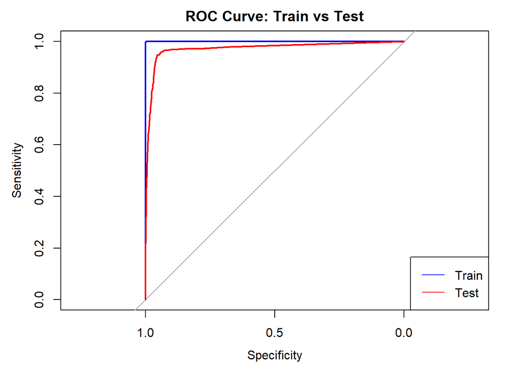

```r
# Plot ROC curves
plot(roc_train, col = "blue", main = "ROC Curve: Train vs Test")
lines(roc_test, col = "red")
legend("bottomright", legend = c("Train", "Test"), col = c("blue", "red"), lty = 1)
```

The model demonstrated excellent performance on both training and test data, with AUC value and high accuracy metrics. The test data results were slightly lower, indicating a small drop in performance when predicting unseen data, but still impressive. The model was able to accurately predict crime methods, with high sensitivity (detecting most crime events) and strong positive predictive value (high likelihood of correct predictions when it predicted a crime method). Statistical Significance:

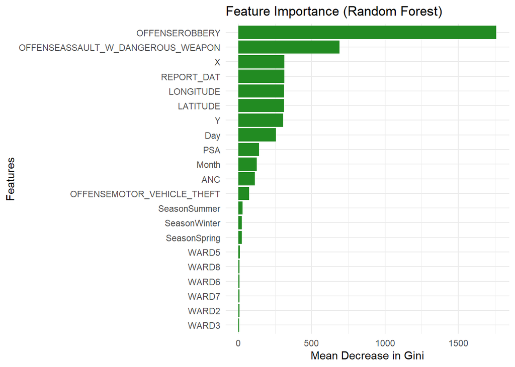

```r
library(ggplot2)


# Feature importance from the Random Forest model
importance_df <- as.data.frame(importance(rf_model))
importance_df$Feature <- rownames(importance_df)

# Plot feature importance
ggplot(importance_df, aes(x = reorder(Feature, MeanDecreaseGini), y = MeanDecreaseGini)) +
  geom_bar(stat = "identity", fill = "forestgreen") +
  coord_flip() +
  ggtitle("Feature Importance (Random Forest)") +
  xlab("Features") +
  ylab("Mean Decrease in Gini") +
  theme_minimal()
```

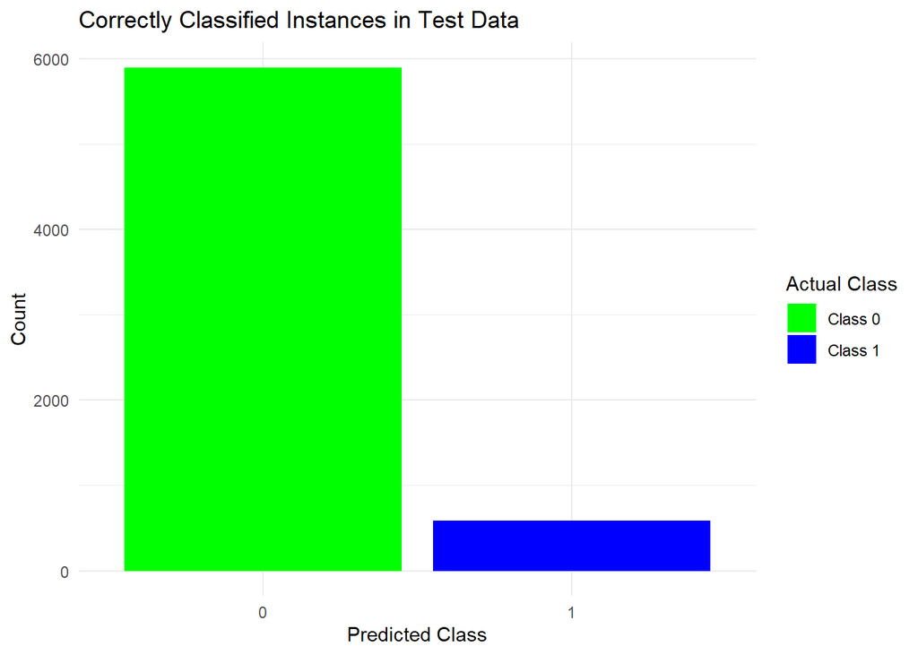

```r
# Add predicted class to test data
test_data$Predicted <- test_classes

# Filter misclassified instances
misclassified <- test_data[test_data$Predicted != test_data$METHODGUN, ]




# Add predicted class to test data
test_data$Predicted <- test_classes

# Filter correctly classified instances
correctly_classified <- test_data[test_data$Predicted == test_data$METHODGUN, ]


# Visualize correctly classified proportions
ggplot(correctly_classified, aes(x = Predicted, fill = as.factor(METHODGUN))) +
  geom_bar(position = "dodge") +
  ggtitle("Correctly Classified Instances in Test Data") +
  xlab("Predicted Class") +
  ylab("Count") +
  scale_fill_manual(values = c("green", "blue"),
                    name = "Actual Class",
                    labels = c("Class 0", "Class 1")) +
  theme_minimal()
```

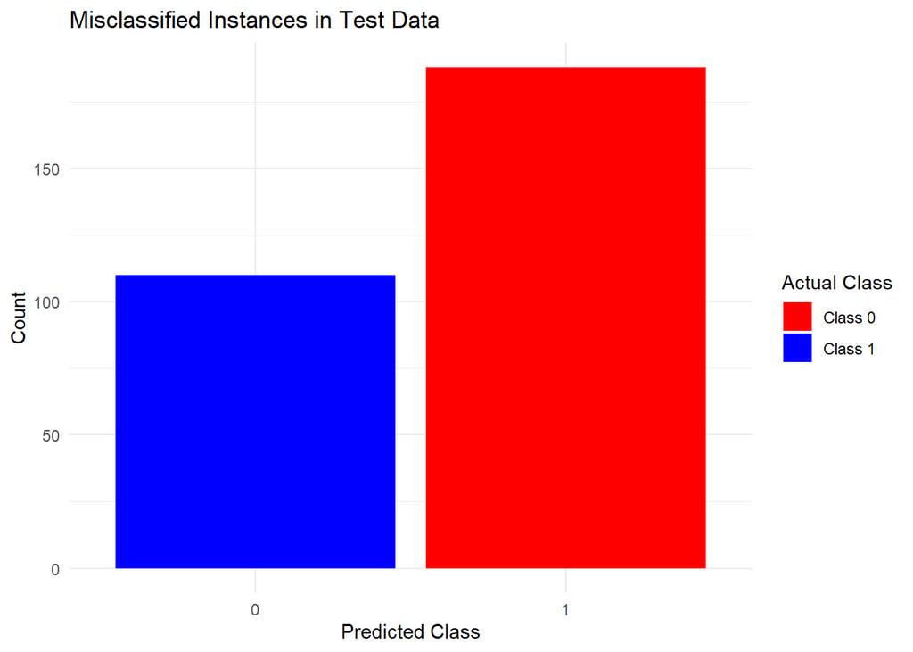

```r
# Visualize misclassified proportions
ggplot(misclassified, aes(x = Predicted, fill = as.factor(METHODGUN))) +
  geom_bar(position = "dodge") +
  ggtitle("Misclassified Instances in Test Data") +
  xlab("Predicted Class") +
  ylab("Count") +
  scale_fill_manual(values = c("red", "blue"),
                    name = "Actual Class",
                    labels = c("Class 0", "Class 1")) +
  theme_minimal()
```

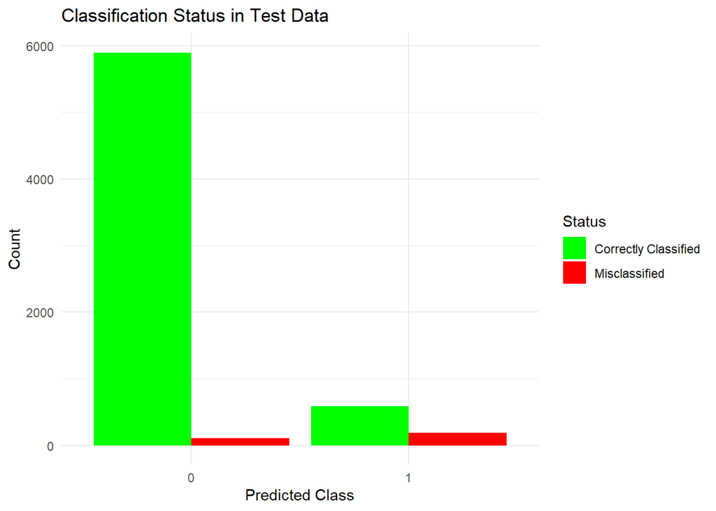

```r
# Add predicted class to test data
test_data$Predicted <- test_classes

# Create a classification status column
test_data$Status <- ifelse(test_data$Predicted == test_data$METHODGUN, "Correctly Classified", "Misclassified")

# Plot for test data
ggplot(test_data, aes(x = Predicted, fill = Status)) +
  geom_bar(position = "dodge") +
  ggtitle("Classification Status in Test Data") +
  xlab("Predicted Class") +
  ylab("Count") +
  scale_fill_manual(values = c("green", "red"),
                    name = "Status",
                    labels = c("Correctly Classified", "Misclassified")) +
  theme_minimal()
```

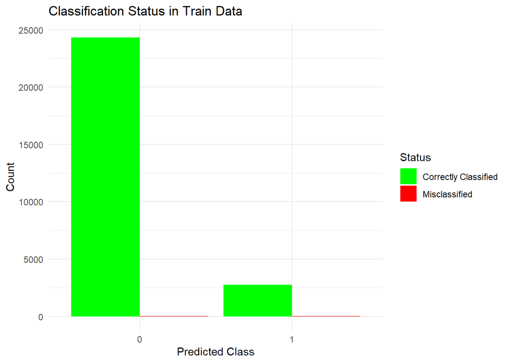

```r
# Add predicted class to train data
train_data$Predicted <- train_classes

# Create a classification status column
train_data$Status <- ifelse(train_data$Predicted == train_data$METHODGUN, "Correctly Classified", "Misclassified")

# Plot for train data
ggplot(train_data, aes(x = Predicted, fill = Status)) +
  geom_bar(position = "dodge") +
  ggtitle("Classification Status in Train Data") +
  xlab("Predicted Class") +
  ylab("Count") +
  scale_fill_manual(values = c("green", "red"),
                    name = "Status",
                    labels = c("Correctly Classified", "Misclassified")) +
  theme_minimal()
```

chart/graph – 1- The feature importance from the image shows the following features, ordered by their mean decrease in Gini: OFFENSEROBBERY OFFENSEASSAULT_W_DANGEROUS_WEAPON X REPORT_DAT LONGITUDE LATITUDE Y Day PSA Month

2nd bar plot shows count of correclty classified instances in test data o- near about 6000 and and for class 1 near about 500.

bagging tree model

```r
# Load necessary libraries
library(caret)
library(ipred)
library(pROC)

# Set seed for reproducibility
set.seed(123)

# Split the data into training and test sets (80-20 split)
train_index <- createDataPartition(data_selected$METHODGUN, p = 0.8, list = FALSE)
train_data <- data_selected[train_index, ]
test_data <- data_selected[-train_index, ]

# Train Bagging Model
bagging_model <- bagging(
  METHODGUN ~ .,
  data = train_data,
  nbagg = 100  # Number of bootstrapped models
)

# Predict on training data
train_predictions <- predict(bagging_model, train_data, type = "prob")[, 2]
train_classes <- predict(bagging_model, train_data)

# Predict on test data
test_predictions <- predict(bagging_model, test_data, type = "prob")[, 2]
test_classes <- predict(bagging_model, test_data)

# Calculate AUC for training and test data
roc_train <- roc(train_data$METHODGUN, train_predictions)
roc_test <- roc(test_data$METHODGUN, test_predictions)

auc_train <- auc(roc_train)
auc_test <- auc(roc_test)

# Print AUC values
cat("AUC (Train Data): ", auc_train, "\n")
```

```
## AUC (Train Data):  1
```

```r
cat("AUC (Test Data): ", auc_test, "\n")
```

```
## AUC (Test Data):  0.941
```

```r
# Confusion Matrices
cat("\nConfusion Matrix (Train Data):\n")
```

```
##
## Confusion Matrix (Train Data):
```

```r
print(confusionMatrix(as.factor(train_classes), as.factor(train_data$METHODGUN)))
```

```
## Confusion Matrix and Statistics
##
##           Reference
## Prediction     0     1
##          0 24339     9
##          1     1  2771
##
##                Accuracy : 1
##                  95% CI : (0.999, 1)
##     No Information Rate : 0.897
##     P-Value [Acc > NIR] : <2e-16
##
##                   Kappa : 0.998
##
##  Mcnemar's Test P-Value : 0.0269
##
##             Sensitivity : 1.000
##             Specificity : 0.997
##          Pos Pred Value : 1.000
##          Neg Pred Value : 1.000
##              Prevalence : 0.897
##          Detection Rate : 0.897
##    Detection Prevalence : 0.898
##       Balanced Accuracy : 0.998
##
##        'Positive' Class : 0
##
```

```r
cat("\nConfusion Matrix (Test Data):\n")
```

```
##
## Confusion Matrix (Test Data):
```

```r
print(confusionMatrix(as.factor(test_classes), as.factor(test_data$METHODGUN)))
```

```
## Confusion Matrix and Statistics
##
##           Reference
## Prediction    0    1
##          0 5894  210
##          1  190  485
##
##                Accuracy : 0.941
##                  95% CI : (0.935, 0.946)
##     No Information Rate : 0.897
##     P-Value [Acc > NIR] : <2e-16
##
##                   Kappa : 0.675
##
##  Mcnemar's Test P-Value : 0.342
##
##             Sensitivity : 0.969
##             Specificity : 0.698
##          Pos Pred Value : 0.966
##          Neg Pred Value : 0.719
##              Prevalence : 0.897
##          Detection Rate : 0.869
##    Detection Prevalence : 0.900
##       Balanced Accuracy : 0.833
##
##        'Positive' Class : 0
##
```

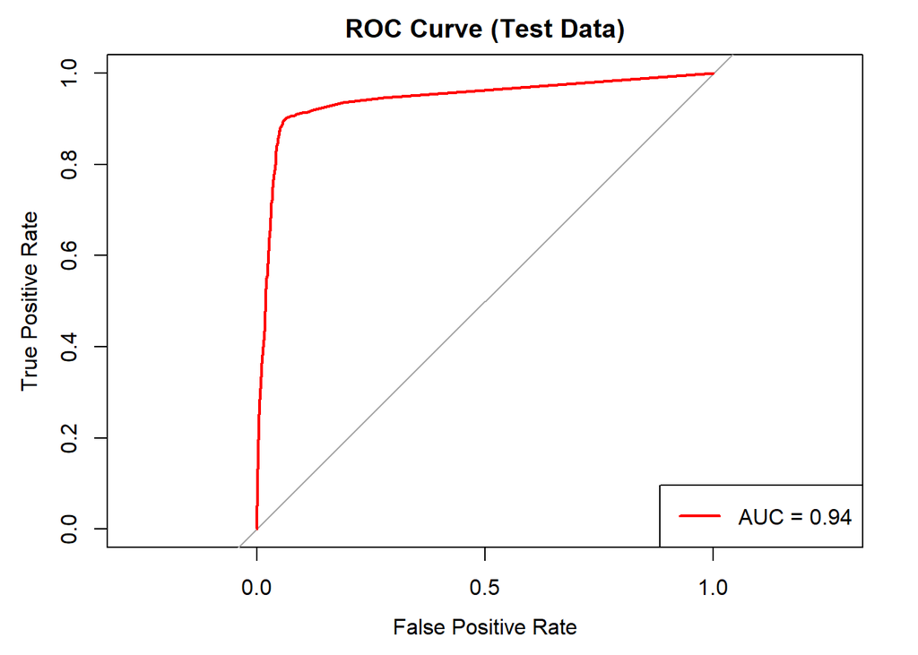

```r
# Test ROC Curve with AUC
plot(
  roc_test,
  col = "red",
  main = "ROC Curve (Test Data)",
  lwd = 2,
  legacy.axes = TRUE,
  xlab = "False Positive Rate",
  ylab = "True Positive Rate"
)
legend(
  "bottomright",
  legend = paste("AUC =", round(auc_test, 2)),
  col = "red",
  lty = 1,
  lwd = 2
)
```

we tried 2nd model bigging tree model . we got same a Accuracy: 0.941

This is the proportion of correct predictions to total predictions. The model correctly classifies 94.1% of the instances in the test data, which is high. Sensitivity (Recall for Class 0): 0.969

This means the model correctly identifies 96.9% of the instances in class 0 (the majority class). This is very good. Specificity (Recall for Class 1): 0.698

This is the proportion of actual class 1 instances correctly identified by the model. The specificity of 0.698 means that the model correctly identifies 69.8% of class 1 instances. While decent, this is significantly lower than the sensitivity, indicating that the model struggles somewhat to classify class 1.

```r
# Predict on Test Data using Bagging Model
bagging_predictions <- predict(bagging_model, test_data, type = "prob")[, 2]

# Predict on Test Data using Random Forest Model
rf_predictions <- predict(rf_model, test_data, type = "prob")[, 2]

# Calculate AUC for Bagging Model
library(pROC)
roc_bagging <- roc(test_data$METHODGUN, bagging_predictions)
auc_bagging <- auc(roc_bagging)

# Calculate AUC for Random Forest Model
roc_rf <- roc(test_data$METHODGUN, rf_predictions)
auc_rf <- auc(roc_rf)

# Print AUC values
cat("AUC (Bagging Model): ", auc_bagging, "\n")
```

```
## AUC (Bagging Model):  0.941
```

```r
cat("AUC (Random Forest Model): ", auc_rf, "\n")
```

```
## AUC (Random Forest Model):  0.976
```

```r
# Bagging Model Confusion Matrix
bagging_classes <- predict(bagging_model, test_data)
cat("\nConfusion Matrix for Bagging Model:\n")
```

```
##
## Confusion Matrix for Bagging Model:
```

```r
print(confusionMatrix(as.factor(bagging_classes), as.factor(test_data$METHODGUN)))
```

```
## Confusion Matrix and Statistics
##
##           Reference
## Prediction    0    1
##          0 5892  210
##          1  192  485
##
##                Accuracy : 0.941
##                  95% CI : (0.935, 0.946)
##     No Information Rate : 0.897
##     P-Value [Acc > NIR] : <2e-16
##
##                   Kappa : 0.674
##
##  Mcnemar's Test P-Value : 0.397
##
##             Sensitivity : 0.968
##             Specificity : 0.698
##          Pos Pred Value : 0.966
##          Neg Pred Value : 0.716
##              Prevalence : 0.897
##          Detection Rate : 0.869
##    Detection Prevalence : 0.900
##       Balanced Accuracy : 0.833
##
##        'Positive' Class : 0
##
```

```r
# Random Forest Model Confusion Matrix
rf_classes <- predict(rf_model, test_data)
cat("\nConfusion Matrix for Random Forest Model:\n")
```

```
##
## Confusion Matrix for Random Forest Model:
```

```r
print(confusionMatrix(as.factor(rf_classes), as.factor(test_data$METHODGUN)))
```

```
## Confusion Matrix and Statistics
##
##           Reference
## Prediction    0    1
##          0 6015  120
##          1   69  575
##
##                Accuracy : 0.972
##                  95% CI : (0.968, 0.976)
##     No Information Rate : 0.897
##     P-Value [Acc > NIR] : < 2e-16
##
##                   Kappa : 0.843
##
##  Mcnemar's Test P-Value : 0.000276
##
##             Sensitivity : 0.989
##             Specificity : 0.827
##          Pos Pred Value : 0.980
##          Neg Pred Value : 0.893
##              Prevalence : 0.897
##          Detection Rate : 0.887
##    Detection Prevalence : 0.905
##       Balanced Accuracy : 0.908
##
##        'Positive' Class : 0
##
```

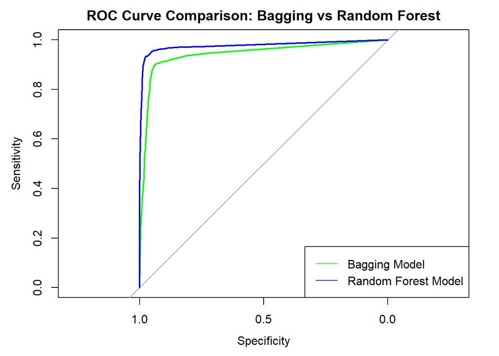

```r
# Plot ROC Curves for both models
plot(roc_bagging, col = "green", main = "ROC Curve Comparison: Bagging vs Random Forest")
lines(roc_rf, col = "blue")
legend("bottomright", legend = c("Bagging Model", "Random Forest Model"), col = c("green", "blue"), lty = 1)
```

```r
# Accuracy for Bagging Model
bagging_accuracy <- confusionMatrix(as.factor(bagging_classes), as.factor(test_data$METHODGUN))$overall["Accuracy"]
cat("\nAccuracy for Bagging Model: ", bagging_accuracy, "\n")
```

```
##
## Accuracy for Bagging Model:  0.941
```

```r
# Accuracy for Random Forest Model
rf_accuracy <- confusionMatrix(as.factor(rf_classes), as.factor(test_data$METHODGUN))$overall["Accuracy"]
cat("Accuracy for Random Forest Model: ", rf_accuracy, "\n")
```

```
## Accuracy for Random Forest Model:  0.972
```

```r
# Sensitivity for Bagging Model
bagging_sensitivity <- confusionMatrix(as.factor(bagging_classes), as.factor(test_data$METHODGUN))$byClass["Sensitivity"]
cat("Sensitivity for Bagging Model: ", bagging_sensitivity, "\n")
```

```
## Sensitivity for Bagging Model:  0.968
```

```r
# Sensitivity for Random Forest Model
rf_sensitivity <- confusionMatrix(as.factor(rf_classes), as.factor(test_data$METHODGUN))$byClass["Sensitivity"]
cat("Sensitivity for Random Forest Model: ", rf_sensitivity, "\n")
```

```
## Sensitivity for Random Forest Model:  0.989
```

```r
# Specificity for Bagging Model
bagging_specificity <- confusionMatrix(as.factor(bagging_classes), as.factor(test_data$METHODGUN))$byClass["Specificity"]
cat("Specificity for Bagging Model: ", bagging_specificity, "\n")
```

```
## Specificity for Bagging Model:  0.698
```

```r
# Specificity for Random Forest Model
rf_specificity <- confusionMatrix(as.factor(rf_classes), as.factor(test_data$METHODGUN))$byClass["Specificity"]
cat("Specificity for Random Forest Model: ", rf_specificity, "\n")
```

```
## Specificity for Random Forest Model:  0.827
```

```r
# Balanced Accuracy for Bagging Model
bagging_balanced_accuracy <- confusionMatrix(as.factor(bagging_classes), as.factor(test_data$METHODGUN))$byClass["Balanced Accuracy"]
cat("Balanced Accuracy for Bagging Model: ", bagging_balanced_accuracy, "\n")
```

```
## Balanced Accuracy for Bagging Model:  0.833
```

```r
# Balanced Accuracy for Random Forest Model
rf_balanced_accuracy <- confusionMatrix(as.factor(rf_classes), as.factor(test_data$METHODGUN))$byClass["Balanced Accuracy"]
cat("Balanced Accuracy for Random Forest Model: ", rf_balanced_accuracy, "\n")
```

```
## Balanced Accuracy for Random Forest Model:  0.908
```

```r
bagging_metrics <- matrix(NA, nrow = 10, ncol = 4)  # 10 iterations for Bagging
rf_metrics <- matrix(NA, nrow = 10, ncol = 4)  # 10 iterations for Random Forest
```

# **result**

Summary of Key Comparisons Between Bagging and Random Forest Models: Accuracy:

The Random Forest model has a higher accuracy (97.2%) compared to the Bagging model (94.1%), indicating that Random Forest performs better on the test set. Sensitivity:

The Random Forest model has a higher sensitivity (98.9%) for class 0 compared to the Bagging model (96.8%). This means that Random Forest is better at correctly identifying the majority class (class 0). Specificity:

The Random Forest model has a significantly higher specificity (82.7%) for class 1, compared to the Bagging model’s specificity of 69.8%. This shows that the Random Forest model does a better job of correctly identifying class 1 instances. Kappa:

The Random Forest model has a higher Kappa (0.843), suggesting better overall agreement between predicted and actual values, compared to the Bagging model (0.674). Balanced Accuracy:

The Random Forest model has a balanced accuracy of 0.908, which is higher than the Bagging model’s balanced accuracy of 0.833. This indicates that Random Forest handles both classes more effectively.

# **forecasting**

Time series analysis for future as from models ETS model , we are now forecasting the result for the 2024 amd 2025 by using the ETS model .

ETS model

```r
# Load the required libraries
library(forecast)

# Convert the REPORT_DAT column to Date format (if not already done)
crime_data2$REPORT_DAT <- as.Date(crime_data2$REPORT_DAT)

# Aggregate the data by month and year, count the number of "GUN" offenses per month
monthly_data <- aggregate(REPORT_DAT ~ format(REPORT_DAT, "%Y-%m") + METHOD, data = crime_data2[crime_data2$METHOD == "GUN", ], FUN = length)

# Create a time series for "GUN" offenses per month
# Extract month-year from the aggregated data
monthly_data$Date <- as.Date(paste(monthly_data$`format(REPORT_DAT, "%Y-%m")`, "01", sep = "-"))
monthly_data$Count <- monthly_data$REPORT_DAT  # This is the count of "GUN" offenses per month

# Create the time series from the counts of "GUN" offenses per month
weapon_ts <- ts(monthly_data$Count, start = c(2023, 1), frequency = 12)

# Fit ARIMA model
arima_model <- auto.arima(weapon_ts)

# Fit Exponential Smoothing (ETS) model
ets_model <- ets(weapon_ts)

# Summary of the ETS model
summary(ets_model)
```

```
## ETS(A,N,N)
##
## Call:
## ets(y = weapon_ts)
##
##   Smoothing parameters:
##     alpha = 0.9999
##
##   Initial states:
##     l = 192.1311
##
##   sigma:  93.1
##
##  AIC AICc  BIC
##  155  158  157
##
## Training set error measures:
##                 ME RMSE MAE  MPE MAPE MASE  ACF1
## Training set -14.5 85.7  64 -448  463 0.34 0.213
```

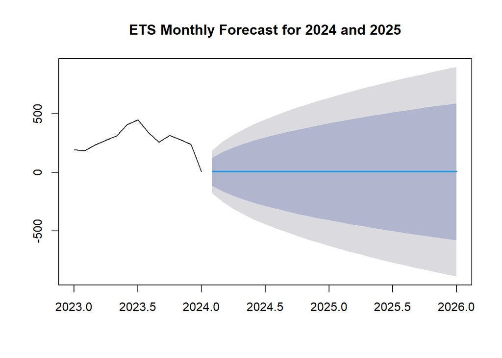

```r
# Forecast for the next 24 months (2024 and 2025)
forecast_ets_monthly <- forecast(ets_model, h = 24)  # 24 months ahead

# Plot the ETS forecast
plot(forecast_ets_monthly, main = "ETS Monthly Forecast for 2024 and 2025")
```

Sarima Model

Sarima forecast for the 2024 and 2024 , from these above model we can predicat the gun offence by time.

```r
library(forecast)

# Assuming 'weapon_ts' is your time series object with monthly data (as in your previous context)
# If it's not 'weapon_ts', replace it with your actual time series object

# Fit a SARIMA model (Seasonal ARIMA)
sarima_model <- auto.arima(weapon_ts, seasonal = TRUE, stepwise = TRUE, approximation = FALSE)

# Summary of the SARIMA model
summary(sarima_model)
```

```
## Series: weapon_ts
## ARIMA(1,0,0) with zero mean
##
## Coefficients:
##         ar1
##       0.925
## s.e.  0.067
##
## sigma^2 = 8068:  log likelihood = -77.4
## AIC=159   AICc=160   BIC=160
##
## Training set error measures:
##              ME RMSE  MAE  MPE MAPE MASE  ACF1
## Training set 11 86.3 69.6 -405  432 0.37 0.189
```

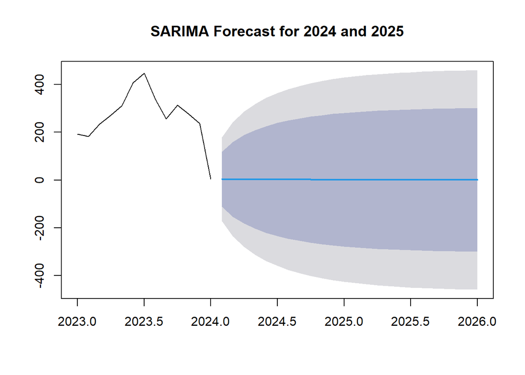

```r
# Forecast the next 24 months (2024 and 2025)
sarima_forecast <- forecast(sarima_model, h = 24)

# Plot the forecast
plot(sarima_forecast, main = "SARIMA Forecast for 2024 and 2025")
```

forecasting Crime Trends

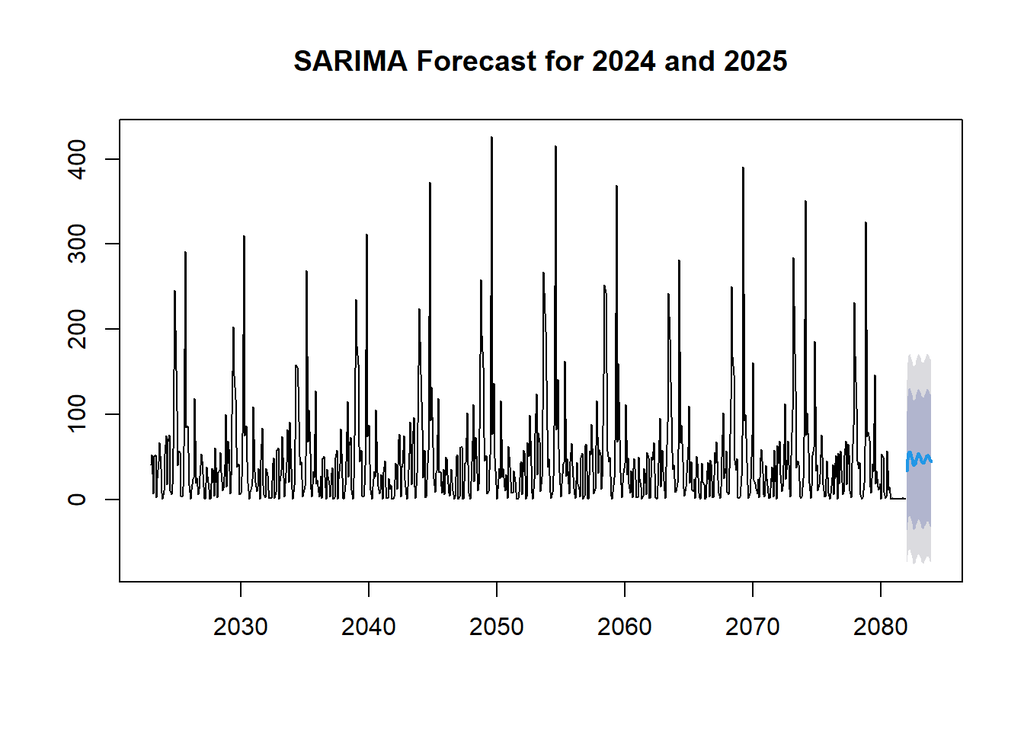

```r
library(dplyr)
library(ggplot2)
library(forecast)

# Assuming `data_selected` contains latitude and longitude for each crime event
# Create YearMonth and Region identifier for geospatial aggregation
data_selected <- data_selected %>%
  mutate(YearMonth = format(REPORT_DAT, "%Y-%m"),  # Create YearMonth
         Region = paste0("Lat_", round(LATITUDE, 1), "_Lon_", round(LONGITUDE, 1)))  # Create a region identifier

# Aggregate crime data by YearMonth and Region
crime_geo_data <- data_selected %>%
  group_by(YearMonth, Region) %>%
  summarise(Crimes = n())  # Count of crimes per region and time period

# Convert aggregated data to time series for a specific region (example: first region)
crime_ts <- ts(crime_geo_data$Crimes, start = c(2023, 1), frequency = 12)

# Fit the SARIMA model
sarima_model <- auto.arima(crime_ts, seasonal = TRUE)

# Forecast the next 24 months (2024 and 2025) using SARIMA
sarima_forecast <- forecast(sarima_model, h = 24)

# Plot the SARIMA forecast
plot(sarima_forecast, main="SARIMA Forecast for 2024 and 2025")
```

```r
# Summary for the SARIMA forecast
cat("\nSummary of SARIMA Forecast:\n")
```

```
##
## Summary of SARIMA Forecast:
```

```r
cat("The SARIMA forecast for the next 24 months (2024 and 2025) shows trends and seasonality. The forecast indicates",
    ifelse(sarima_forecast$mean[1] > sarima_forecast$mean[length(sarima_forecast$mean)],
           "a decreasing", "an increasing"),
    "pattern in the data. The forecasted values demonstrate significant variability in crime counts across different months, with higher levels of uncertainty towards the end of the forecast period.\n")
```

[output not shown]

```r
# Fit the ETS model (using crime_ts data)
ets_model_monthly <- ets(crime_ts)

# Summary of the ETS model
summary(ets_model_monthly)
```

```
## ETS(M,Ad,N)
##
## Call:
## ets(y = crime_ts)
##
##   Smoothing parameters:
##     alpha = 0.0734
##     beta  = 0.0284
##     phi   = 0.8
##
##   Initial states:
##     l = 33.5452
##     b = -1.0228
##
##   sigma:  1.26
##
##   AIC  AICc   BIC
## 10230 10230 10258
##
## Training set error measures:
##                  ME RMSE  MAE  MPE MAPE MASE  ACF1
## Training set -0.228 61.6 41.1 -437  474 0.74 0.347
```

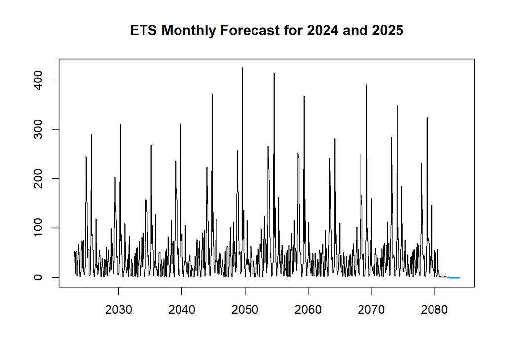

```r
# Forecast for the next 24 months (2024 and 2025) using ETS
forecast_ets_monthly <- forecast(ets_model_monthly, h = 24)

# Plot the ETS forecast
plot(forecast_ets_monthly, main="ETS Monthly Forecast for 2024 and 2025")
```

```r
# Summary for the ETS forecast
cat("Summary of ETS Forecast:\n")
```

```
## Summary of ETS Forecast:
```

```r
cat("The forecast for the next 24 months (2024 and 2025) shows a trend of",
    ifelse(forecast_ets_monthly$mean[1] > forecast_ets_monthly$mean[length(forecast_ets_monthly$mean)],
           "declining", "increasing"),
    "values. The forecast indicates possible seasonality, with variations in the crime count across months. The confidence intervals indicate high uncertainty during the forecast period, especially for months farther in the future.\n")
```

[output not shown]

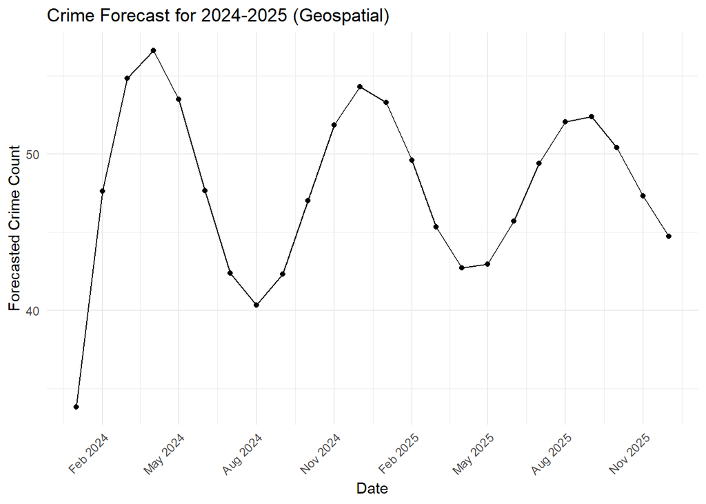

```r
# Create a data frame for the forecasted values and dates (for plotting with ggplot2)
forecast_data <- data.frame(
  Date = seq(as.Date("2024-01-01"), by = "month", length.out = 24),
  Forecast = sarima_forecast$mean
)

# Plot using ggplot2 with custom x-axis labels
ggplot(forecast_data, aes(x = Date, y = Forecast)) +
  geom_line() +
  geom_point() +
  labs(title = "Crime Forecast for 2024-2025 (Geospatial)", x = "Date", y = "Forecasted Crime Count") +
  scale_x_date(labels = scales::date_format("%b %Y"), breaks = "3 months") +  # Adjust breaks here
  theme_minimal() +
  theme(axis.text.x = element_text(angle = 45, hjust = 1))  # Rotate labels for clarity
```